# Basics of working with paleobiological fossil data

An operational learning approach to the essential computational competencies you need for your research, from ideas to publication and beyond

Author

Jeet Sukumaran

**Proficiencies**

- Background concepts:
  - What the Paleobiology Database is and what kinds of data it holds
  - What a fossil *occurrence* record is, and what the fields `min_ma` / `max_ma` / `direct_ma` encode
  - Why data quality has three distinct dimensions: taxonomic resolution, chronological precision, and spatial completeness
  - Why real-world data retrieved from a live API will almost always contain missing values, and why that matters before any analysis or plotting
- Core skills:
  - Exploring the `PaleobiologyDB.jl` package API and its built-in documentation system
  - Calling `pbdb_occurrences` with the parameters `base_name`, `show`, `vocab`, `extids`, and `limit`
  - Inspecting column names, types, and missing-value counts returned by an API query
  - Filtering by taxonomic rank using `filter` and reviewing equivalent approaches with `subset` and boolean indexing
  - Detecting data coverage across multiple chronological fields using regex column selection
  - Removing rows with missing values using `dropmissing` on targeted column sets
  - Assessing taxonomic diversity with `groupby` and `combine`
  - Computing a derived column (temporal midpoint) with `transform`
  - Plotting fossil occurrence locations on a world map using `GeoMakie.GeoAxis`
  - Adding land outlines with `poly!` and occurrence points with `scatter!`
  - Encoding age as color using a continuous colormap and `Colorbar`
  - Plotting temporal distributions with `hist!` and a reversed time axis

## 1 Walkthrough of an example analysis

This tutorial introduces you to the digital side of paleontology. Instead of manually shading paper charts, you will use Julia to “hunt” for fossils across the globe. We will focus on the **Canidae** (the dog family) during the **Miocene** (about 23 to 5 million years ago), a critical time for their diversification.

**Proficiencies**

By the end of this activity, you will be able to:

1. **Download** real fossil data directly from the Paleobiology Database.
2. **Clean** that data so it is ready for a map.
3. **Visualize** exactly where these ancient dogs lived using a geographic map.

### 1.1 Preparation: Loading Your Tools

```julia
using PaleobiologyDB
using DataFrames
using GeoMakie, CairoMakie
```

### 1.2 Step 1: Download the Data

We will ask the database for every recorded occurrence of a Canidae fossil from the Miocene epoch. We specifically request **coordinates** so we know where each specimen was found.

```julia
canids = pbdb_occurrences(
    base_name = "Canidae",
    interval  = "Miocene",
    show      = ["coords", "classext"],
    vocab     = "pbdb"
)

println("Found ", nrow(canids), " Miocene canid fossils!")
```

```
Found 1345 Miocene canid fossils!
```

**Note**

### 1.3 Step 2: Clean the Data

Real-world data is often messy. Some fossil records may be missing exact GPS coordinates. Before we can make a map, we must remove any rows that lack a latitude or longitude value.

```julia
clean_canids = dropmissing(canids, [:lat, :lng])

println("Records with valid coordinates: ", nrow(clean_canids))
println("Records dropped: ", nrow(canids) - nrow(clean_canids))
```

```
Records with valid coordinates: 1345
Records dropped: 0
```

### 1.4 Step 3: Visualize on a World Map

Now we will plot these points on a world map. In the Miocene the continents were roughly where they are today, but the climate and faunal dispersal corridors were quite different.

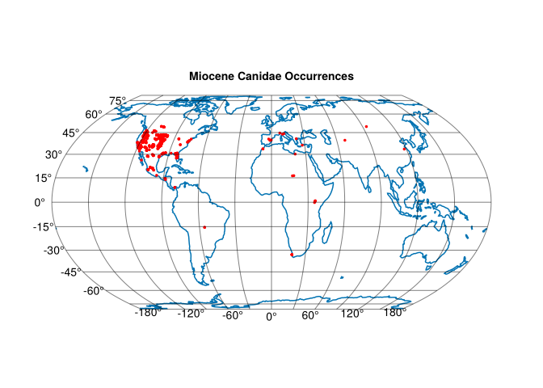

```
CairoMakie.Screen{IMAGE}
```

```julia
fig = Figure()
ax  = GeoAxis(fig[1, 1]; title = "Miocene Canidae Occurrences")

lines!(ax, GeoMakie.coastlines())  # land reference — without this the plot is blank
scatter!(ax, clean_canids.lng, clean_canids.lat;
         color = :red, markersize = 5)

display(fig)
```

### 1.5 Biological Context & Analysis

**Exercise 1**

Examine your map and address the following questions:

1. **Geographic Distribution** — Are the fossils concentrated on one continent (such as North America) or spread across multiple landmasses? Many canid lineages were actively diversifying and dispersing during the Miocene.
2. **Environmental Context** — Many Miocene canids were adapting to the expansion of open grasslands. Do the fossil localities correspond to regions that are currently deserts, forests, or plains?
3. **Data Quality** — Are there conspicuous gaps on your map? Absence of points does not necessarily mean canids were absent; it may reflect gaps in collection or digitization effort in those regions.

### 1.6 Optional: Compare with Another Taxon

Try swapping out the taxon and time interval to see a very different biogeographic pattern — the Cambrian Explosion of marine invertebrates.

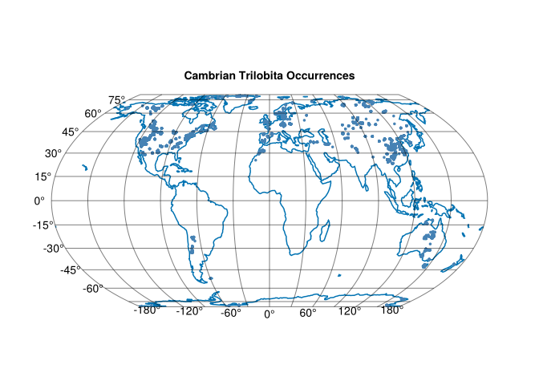

```
CairoMakie.Screen{IMAGE}
```

```julia
trilobites = pbdb_occurrences(
    base_name = "Trilobita",
    interval  = "Cambrian",
    show      = ["coords", "classext"],
    vocab     = "pbdb"
)

clean_trilobites = dropmissing(trilobites, [:lat, :lng])

fig2 = Figure()
ax2  = GeoAxis(fig2[1, 1]; title = "Cambrian Trilobita Occurrences")

lines!(ax2, GeoMakie.coastlines())
scatter!(ax2, clean_trilobites.lng, clean_trilobites.lat;
         color = :steelblue, markersize = 5)

display(fig2)
```

**Tip**

Compare the global spread of Cambrian trilobites with the distribution of Miocene canids. What does the difference in spatial pattern tell you about marine versus terrestrial dispersal during these two intervals?

## 2 Basics of data acquisition and preparation

**Proficiencies**

- Background concepts:
  - What the Paleobiology Database is and what kinds of data it holds
  - What a fossil *occurrence* record is, and what the fields `min_ma` / `max_ma` / `direct_ma` encode
  - Why data quality has three distinct dimensions: taxonomic resolution, chronological precision, and spatial completeness
  - Why real-world data retrieved from a live API will almost always contain missing values, and why that matters before any analysis or plotting
- Core skills:
  - Exploring the `PaleobiologyDB.jl` package API and its built-in documentation system
  - Calling `pbdb_occurrences` with the parameters `base_name`, `show`, `vocab`, `extids`, and `limit`
  - Inspecting column names, types, and missing-value counts returned by an API query
  - Filtering by taxonomic rank using `filter` and reviewing equivalent approaches with `subset` and boolean indexing
  - Detecting data coverage across multiple chronological fields using regex column selection
  - Removing rows with missing values using `dropmissing` on targeted column sets
  - Assessing taxonomic diversity with `groupby` and `combine`
  - Computing a derived column (temporal midpoint) with `transform`
  - Plotting fossil occurrence locations on a world map using `GeoMakie.GeoAxis`
  - Adding land outlines with `poly!` and occurrence points with `scatter!`
  - Encoding age as color using a continuous colormap and `Colorbar`
  - Plotting temporal distributions with `hist!` and a reversed time axis

### 2.1 The Paleobiology Database

The [Paleobiology Database](https://paleobiodb.org/) (PBDB) is a community-curated, openly accessible repository of fossil occurrence records spanning the history of life on Earth. Each record — an *occurrence* — documents that a particular taxon was found at a particular place, in a stratigraphic unit of known geological age. The PBDB currently holds several million such records contributed by researchers worldwide.

**TipOccurrences, collections, and taxa**

The PBDB organizes its data around three main entities.

A **collection** is a set of fossils from the same physical locality and stratigraphic context — essentially one fossil site. An **occurrence** links a taxon to a collection: it records that taxon *X* was identified in collection *Y*. A **taxon** record holds the name, classification, and synonymy information for a biological group.

When we ask for “occurrences of Canidae,” we are asking for every row in the database that links a canid identification to a dated collection, along with the geographic and stratigraphic context of that collection.

The `PaleobiologyDB.jl` package provides a Julia interface to the PBDB’s web API. Every API endpoint corresponds to a Julia function; calling the function returns a `DataFrame`.

### 2.2 Setting up the environment

We will use four packages in this chapter. `PaleobiologyDB` fetches data from the PBDB API. `DataFrames` is the standard Julia tabular-data package we used in the previous chapter. `CairoMakie` is the rendering backend for Makie plots. `GeoMakie` extends Makie with geographic axes and projections — we introduce it below.

```julia
using Pkg
Pkg.add(["PaleobiologyDB", "GeoMakie", "CairoMakie", "DataFrames"])
```

You can confirm which versions are active at any time:

```julia
using Pkg
Pkg.status()
```

```
Status `~/site/storage/local/authoring/teaching/20260315_just-enough-julia/20260108_just-enough-julia-for-scientific-reasoning/20260108_just-enough-julia-for-scientific-reasoning/Project.toml`
  [46ada45e] Agents v7.0.0
⌃ [13f3f980] CairoMakie v0.15.8
  [a93c6f00] DataFrames v1.8.1
  [31c24e10] Distributions v0.25.123
  [dedd4f52] GBIF2 v0.2.1
⌃ [e9467ef8] GLMakie v0.13.8
  [db073c08] GeoMakie v0.7.16
⌅ [ee78f7c6] Makie v0.24.8
⌃ [ee6415c8] OccurrencesInterface v1.2.1
  [c9cb2f45] PaleobiologyDB v1.1.2
⌃ [91a5bcdd] Plots v1.41.5
⌃ [72b53823] SpeciesDistributionToolkit v1.8.1
  [2913bbd2] StatsBase v0.34.10
  [9a3f8284] Random v1.11.0
Info Packages marked with ⌃ and ⌅ have new versions available. Those with ⌃ may be upgradable, but those with ⌅ are restricted by compatibility constraints from upgrading. To see why use `status --outdated`
```

After installation, load the packages:

```julia
using PaleobiologyDB
using DataFrames
using CairoMakie
using GeoMakie
```

### 2.3 Exploring the package

Before retrieving any data, it is worth understanding what functions `PaleobiologyDB` exposes. The package models the PBDB API closely, so listing its exported names gives you a map of the available endpoints:

```julia
foreach(println, names(PaleobiologyDB))
```

```
PaleobiologyDB
pbdb_collection
pbdb_collections
pbdb_collections_geo
pbdb_config
pbdb_interval
pbdb_intervals
pbdb_measurements
pbdb_occurrence
pbdb_occurrences
pbdb_opinion
pbdb_opinions
pbdb_opinions_taxa
pbdb_ref_collections
pbdb_ref_occurrences
pbdb_ref_specimens
pbdb_ref_taxa
pbdb_reference
pbdb_references
pbdb_scale
pbdb_scales
pbdb_specimen
pbdb_specimens
pbdb_strata
pbdb_strata_auto
pbdb_taxa
pbdb_taxa_auto
pbdb_taxon
```

`pbdb_occurrences` is the function we want. Read its documentation directly in the notebook:

```julia
@doc pbdb_occurrences
```

```
pbdb_occurrences(; kwargs...)
```

Get information about fossil occurrence records stored in the Paleobiology Database.

Arguments

- `kwargs...`: Filtering and output parameters. Common options include:

  - `limit`: Maximum number of records to return (`Int` or `"all"`).

  - `taxon_name`: Return only records with the specified taxonomic name(s).

  - `base_name`: Return records for the specified name(s) and all descendant taxa.

  - `lngmin`, `lngmax`, `latmin`, `latmax`: Geographic bounding box.

  - `min_ma`, `max_ma`: Minimum and maximum age in millions of years.

  - `interval`: Named geologic interval (e.g. `"Miocene"`).

  - `cc`: Country/continent codes (ISO two-letter or three-letter).

  - `show`: Extra information blocks (`"coords"`, `"classext"`, `"ident"`, etc.). `show = "full"` for everything.

  - `extids`: Set `extids = true` to show the newer string identifiers.

  - `vocab`: Vocabulary for field names (`"pbdb"` for full names, `"com"` for short codes).

Returns

A `DataFrame` with fossil occurrence records matching the query.

Examples

```
# `taxon_name` retrieves *only* units of this rank
occs = pbdb_occurrences(
    taxon_name="Canis",
    show="full", # all columns
    limit=100,
)

# `base_name` retrieves units of this and nested rank
occs = pbdb_occurrences(
    base_name="Canis",
    show=["coords","classext"],
    limit=100,
)
```

**TipPBDB data service API help**

The `PaleobiologyDB` package includes a built-in help system that mirrors the upstream API documentation, going well beyond what fits in a single function docstring:

```julia
using PaleobiologyDB.ApiHelp
names(ApiHelp)
```

There is even help on using the help system itself:

```julia
?ApiHelp
?pbdb_help()
?pbdb_endpoints()
?pbdb_parameters()
?pbdb_fields()
?pbdb_search()
```

This is particularly useful when you want to know which `show` blocks are available, what each field name means, or how to construct a bounding-box query.

### 2.4 Acquiring occurrence data

The primary function for retrieving occurrence records is `pbdb_occurrences`. Its arguments map directly onto the PBDB API’s query parameters.

When first exploring a new group, request a limited sample so the API call is fast and the result is manageable:

```julia
occs = pbdb_occurrences(
    ;   # the ';' indicates end of positional arguments
    base_name = "Carnivora",
    show      = "full",
    vocab     = "pbdb",
    extids    = true,
    limit     = 1000,
)
```

1000×135 DataFrame

35 columns and 975 rows omitted

| Row | occurrence_no String15 | reid_no String15? | flags Missing | collection_no String15 | identified_name String | identified_rank String15 | identified_no String15 | difference String31? | accepted_name String | accepted_attr Missing | accepted_rank String15 | accepted_no String15 | early_interval String31 | late_interval String31? | max_ma Float64 | min_ma Float64 | ref_author String31 | ref_pubyr Int64 | reference_no String15 | phylum String15 | class String15 | order String15 | family String31 | genus String31 | plant_organ Missing | abund_value Int64? | abund_unit String15? | lng Float64 | lat Float64 | … |
| --- | --- | --- | --- | --- | --- | --- | --- | --- | --- | --- | --- | --- | --- | --- | --- | --- | --- | --- | --- | --- | --- | --- | --- | --- | --- | --- | --- | --- | --- | --- |
| 1 | occ:117266 | missing | missing | col:9070 | Cynodictis lacustris | species | txn:349281 | missing | Cynodictis lacustris | missing | species | txn:349281 | Late Eocene | missing | 37.71 | 33.9 | Hooker 1994 | 1994 | ref:11154 | Chordata | Mammalia | Carnivora | Amphicyonidae | Cynodictis | missing | missing | missing | -1.0856 | 50.6772 | … |
| 2 | occ:137493 | missing | missing | col:11601 | Enaliarctos mealsi n. gen. n. sp. | species | txn:71871 | missing | Enaliarctos mealsi | missing | species | txn:71871 | Chattian | missing | 27.3 | 23.04 | Mitchell and Tedford 1973 | 1973 | ref:4383 | Chordata | Mammalia | Carnivora | NO_FAMILY_SPECIFIED | Enaliarctos | missing | 14 | specimens | -118.848 | 35.4928 | … |
| 3 | occ:137495 | missing | missing | col:11601 | Pinnarctidion bishopi | species | txn:72007 | missing | Pinnarctidion bishopi | missing | species | txn:72007 | Chattian | missing | 27.3 | 23.04 | Barnes 1979 | 1979 | ref:4175 | Chordata | Mammalia | Carnivora | NO_FAMILY_SPECIFIED | Pinnarctidion | missing | 2 | specimens | -118.848 | 35.4928 | … |
| 4 | occ:138737 | missing | missing | col:11798 | Indarctos sinensis | species | txn:90198 | missing | Indarctos atticus | missing | species | txn:90196 | Tortonian | missing | 11.63 | 7.246 | Qi 1985 | 1985 | ref:11437 | Chordata | Mammalia | Carnivora | Ursidae | Indarctos | missing | missing |  | 102.067 | 25.0167 | … |
| 5 | occ:138738 | missing | missing | col:11798 | Protursus sp. | genus | txn:116932 | missing | Protursus | missing | genus | txn:116932 | Tortonian | missing | 11.63 | 7.246 | Qi 1985 | 1985 | ref:11437 | Chordata | Mammalia | Carnivora | Ailuridae | Protursus | missing | missing |  | 102.067 | 25.0167 | … |
| 6 | occ:138739 | missing | missing | col:11798 | Ursinae indet. | subfamily | txn:65407 | missing | Ursinae | missing | subfamily | txn:65407 | Tortonian | missing | 11.63 | 7.246 | Qi 1985 | 1985 | ref:10885 | Chordata | Mammalia | Carnivora | Ursidae |  | missing | missing |  | 102.067 | 25.0167 | … |
| 7 | occ:138740 | missing | missing | col:11798 | Proputorius lufengensis | species | var:509396 | recombined as | Cernictis lufengensis | missing | species | txn:509396 | Tortonian | missing | 11.63 | 7.246 | Qi 1985 | 1985 | ref:11437 | Chordata | Mammalia | Carnivora | Mustelidae | Cernictis | missing | missing |  | 102.067 | 25.0167 | … |
| 8 | occ:138741 | missing | missing | col:11798 | Sivaonyx bathygnathus | species | txn:438269 |  | Sivaonyx bathygnathus | missing | species | txn:156337 | Tortonian | missing | 11.63 | 7.246 | Qi 1985 | 1985 | ref:11437 | Chordata | Mammalia | Carnivora | Mustelidae | Sivaonyx | missing | missing |  | 102.067 | 25.0167 | … |
| 9 | occ:138742 | missing | missing | col:11798 | Lutra sp. | genus | txn:41122 |  | Lutra | missing | genus | txn:41122 | Tortonian | missing | 11.63 | 7.246 | Qi 1985 | 1985 | ref:11437 | Chordata | Mammalia | Carnivora | Mustelidae | Lutra | missing | missing |  | 102.067 | 25.0167 | … |
| 10 | occ:138743 | missing | missing | col:11798 | Ictitherium gaudryi | genus | txn:41026 | species not entered | Ictitherium | missing | genus | txn:41026 | Tortonian | missing | 11.63 | 7.246 | Qi 1985 | 1985 | ref:11437 | Chordata | Mammalia | Carnivora | Hyaenidae | Ictitherium | missing | missing |  | 102.067 | 25.0167 | … |
| 11 | occ:138744 | missing | missing | col:11798 | Viverrinae indet. | subfamily | txn:72213 |  | Viverrinae | missing | subfamily | txn:72213 | Tortonian | missing | 11.63 | 7.246 | Qi 1985 | 1985 | ref:11437 | Chordata | Mammalia | Carnivora | Viverridae |  | missing | missing |  | 102.067 | 25.0167 | … |
| 12 | occ:138826 | missing | missing | col:11799 | Machaerodus sp. | genus | txn:47826 |  | Machaerodus | missing | genus | txn:47826 | Late Miocene | Early Pliocene | 11.63 | 3.6 | Maxson 1946 | 1946 | ref:4198 | Chordata | Mammalia | Carnivora | Felidae | Machaerodus | missing | missing |  | 32.8667 | 39.9333 | … |
| 13 | occ:147936 | missing | missing | col:13061 | Atopotarus courseni n. gen. n. sp. | species | txn:53071 |  | Atopotarus courseni | missing | species | txn:53071 | Late Hemingfordian | Early Barstovian | 18.5 | 12.5 | Downs 1956 | 1956 | ref:4342 | Chordata | Mammalia | Carnivora | Desmatophocidae | Atopotarus | missing | missing |  | -118.34 | 33.773 | … |
| ⋮ | ⋮ | ⋮ | ⋮ | ⋮ | ⋮ | ⋮ | ⋮ | ⋮ | ⋮ | ⋮ | ⋮ | ⋮ | ⋮ | ⋮ | ⋮ | ⋮ | ⋮ | ⋮ | ⋮ | ⋮ | ⋮ | ⋮ | ⋮ | ⋮ | ⋮ | ⋮ | ⋮ | ⋮ | ⋮ | … |
| 989 | occ:183590 |  | missing | col:17925 | Mesocyon socialis | genus | txn:41220 | species not entered | Mesocyon | missing | genus | txn:41220 | Early Hemingfordian |  | 18.5 | 16.3 | Fremd 1994 | 1994 | ref:1547 | Chordata | Mammalia | Carnivora | Canidae | Mesocyon | missing | missing |  | -120.2 | 44.9 | … |
| 990 | occ:183591 |  | missing | col:17925 | Paradaphoenus sp. | genus | txn:41289 |  | Paradaphoenus | missing | genus | txn:41289 | Early Hemingfordian |  | 18.5 | 16.3 | Fremd 1994 | 1994 | ref:1547 | Chordata | Mammalia | Carnivora | Amphicyonidae | Paradaphoenus | missing | missing |  | -120.2 | 44.9 | … |
| 991 | occ:183607 |  | missing | col:17927 | Cynarctoides acridens | species | txn:45433 |  | Cynarctoides acridens | missing | species | txn:45441 | Early Hemingfordian |  | 18.5 | 16.3 | Wang et al. 1999 | 1999 | ref:3558 | Chordata | Mammalia | Carnivora | Canidae | Cynarctoides | missing | missing |  | -103.1 | 42.8 | … |
| 992 | occ:183608 |  | missing | col:17927 | Desmocyon matthewi | species | txn:45610 |  | Desmocyon matthewi | missing | species | txn:45610 | Early Hemingfordian |  | 18.5 | 16.3 | Wang et al. 1999 | 1999 | ref:3558 | Chordata | Mammalia | Carnivora | Canidae | Desmocyon | missing | missing |  | -103.1 | 42.8 | … |
| 993 | occ:183615 |  | missing | col:17928 | Desmocyon matthewi | species | txn:45610 |  | Desmocyon matthewi | missing | species | txn:45610 | Early Hemingfordian |  | 18.5 | 16.3 | Wang et al. 1999 | 1999 | ref:3558 | Chordata | Mammalia | Carnivora | Canidae | Desmocyon | missing | missing |  | -103.1 | 42.8 | … |
| 994 | occ:183616 |  | missing | col:17929 | Cynarctoides acridens | species | txn:45433 |  | Cynarctoides acridens | missing | species | txn:45441 | Early Hemingfordian |  | 18.5 | 16.3 | Wang et al. 1999 | 1999 | ref:3558 | Chordata | Mammalia | Carnivora | Canidae | Cynarctoides | missing | missing |  | -103.1 | 42.2 | … |
| 995 | occ:183622 |  | missing | col:17932 | Cynarctoides acridens | species | txn:45433 |  | Cynarctoides acridens | missing | species | txn:45441 | Early Hemingfordian |  | 18.5 | 16.3 | Wang et al. 1999 | 1999 | ref:3558 | Chordata | Mammalia | Carnivora | Canidae | Cynarctoides | missing | missing |  | -103.1 | 42.2 | … |
| 996 | occ:183623 |  | missing | col:17932 | Phlaocyon marslandensis | species | txn:50347 |  | Phlaocyon marslandensis | missing | species | txn:50347 | Early Hemingfordian |  | 18.5 | 16.3 | Wang et al. 1999 | 1999 | ref:3558 | Chordata | Mammalia | Carnivora | Canidae | Phlaocyon | missing | missing |  | -103.1 | 42.2 | … |
| 997 | occ:183624 |  | missing | col:17932 | Desmocyon matthewi | species | txn:45610 |  | Desmocyon matthewi | missing | species | txn:45610 | Early Hemingfordian |  | 18.5 | 16.3 | Wang et al. 1999 | 1999 | ref:3558 | Chordata | Mammalia | Carnivora | Canidae | Desmocyon | missing | missing |  | -103.1 | 42.2 | … |
| 998 | occ:183625 |  | missing | col:17932 | Metatomarctus canavus | species | txn:48462 |  | Metatomarctus canavus | missing | species | txn:45454 | Early Hemingfordian |  | 18.5 | 16.3 | Wang et al. 1999 | 1999 | ref:3558 | Chordata | Mammalia | Carnivora | Canidae | Metatomarctus | missing | missing |  | -103.1 | 42.2 | … |
| 999 | occ:183626 | rei:30999 | missing | col:17933 | Daphoenodon (Borocyon) robustum | species | txn:318454 |  | Daphoenodon (Borocyon) robustum | missing | species | txn:44589 | Early Hemingfordian |  | 18.5 | 16.3 | Hunt 2009 | 2009 | ref:54871 | Chordata | Mammalia | Carnivora | Amphicyonidae | Daphoenodon (Borocyon) | missing | missing |  | -103.1 | 42.2 | … |
| 1000 | occ:183627 |  | missing | col:17934 | Cynarctoides acridens | species | txn:45433 |  | Cynarctoides acridens | missing | species | txn:45441 | Early Hemingfordian |  | 18.5 | 16.3 | Wang et al. 1999 | 1999 | ref:3558 | Chordata | Mammalia | Carnivora | Canidae | Cynarctoides | missing | missing |  | -103.1 | 42.2 | … |

**TipWhat the key arguments do**

`base_name = "Carnivora"` retrieves occurrences for *Carnivora* and all of its nested descendant taxa. Using `taxon_name` instead would restrict results to records identified to exactly that name.

`show = "full"` requests the complete set of response fields, including geographic coordinates, paleocoordinates, classification hierarchy, and stratigraphic details. You can also pass a list of specific blocks — for example `show = ["coords", "class"]` — to request only what you need.

`vocab = "pbdb"` uses the long, human-readable field names (e.g. `accepted_name`, `early_interval`) rather than the compact API codes.

`extids = true` returns modern string-style record identifiers (e.g. `"occ:12345"`) rather than bare integers.

`limit = 1000` caps the number of records returned. Remove the limit (or set `limit = "all"`) only when you are ready to work with the full dataset.

The return value is a standard `DataFrame`:

```julia
typeof(occs)
```

```
DataFrame
```

```julia
size(occs)
```

```
(1000, 135)
```

### 2.5 Inspecting the data

Before doing anything else, examine what came back.

#### 2.5.1 List the columns of the dataset

The function `foreach` applies the first argument, a function, to every element of the second argument. Here the first argument is `println` and the second argument is `names(occs)`. The function call `names(occs)` returns all the column names of the `DataFrame` object passed to it, `occs`. Put altogether: the `names(occs)` call returns an array of column names, and the `foreach` function then applies the `println` function to each element of this array, which prints the column name out to the standard output. The end result is each column name in the `occs` `DataFrame` being printed on its own line.

```julia
foreach(println, names(occs))
```

```
occurrence_no
reid_no
flags
collection_no
identified_name
identified_rank
identified_no
difference
accepted_name
accepted_attr
accepted_rank
accepted_no
early_interval
late_interval
max_ma
min_ma
ref_author
ref_pubyr
reference_no
phylum
class
order
family
genus
plant_organ
abund_value
abund_unit
lng
lat
occurrence_comments
collection_name
container_no
collection_aka
cc
state
county
latlng_basis
latlng_precision
altitude_value
altitude_unit
```

[output cut: 80 more lines]

```
taxonomy_comments
research_group
taxon_environment
environment_basis
motility
life_habit
vision
diet
reproduction
ontogeny
ecospace_comments
composition
architecture
thickness
reinforcement
```

#### 2.5.2 Detailed summary of the dataset structure

`describe` gives the most useful first-look summary: column name, element type, and the number of missing values in each column.

```julia
describe(occs)
```

135×7 DataFrame

110 rows omitted

| Row | variable Symbol | mean Union… | min Any | median Union… | max Any | nmissing Int64 | eltype Type |
| --- | --- | --- | --- | --- | --- | --- | --- |
| 1 | occurrence_no |  | occ:117266 |  | occ:183627 | 0 | String15 |
| 2 | reid_no |  |  |  | rei:674 | 27 | Union{Missing, String15} |
| 3 | flags |  |  |  |  | 1000 | Missing |
| 4 | collection_no |  | col:11601 |  | col:99845 | 0 | String15 |
| 5 | identified_name |  | "Hesperocyon" coloradensis |  | cf. Promartes sp. | 0 | String |
| 6 | identified_rank |  | family |  | suborder | 0 | String15 |
| 7 | identified_no |  | txn:104016 |  | var:52393 | 0 | String15 |
| 8 | difference |  |  |  | species not entered | 6 | Union{Missing, String31} |
| 9 | accepted_name |  | Acheronictis webbi |  | Zodiolestes daimonelixensis | 0 | String |
| 10 | accepted_attr |  |  |  |  | 1000 | Missing |
| 11 | accepted_rank |  | family |  | suborder | 0 | String15 |
| 12 | accepted_no |  | txn:100309 |  | txn:90655 | 0 | String15 |
| 13 | early_interval |  | Arikareean |  | Whitneyan | 0 | String31 |
| ⋮ | ⋮ | ⋮ | ⋮ | ⋮ | ⋮ | ⋮ | ⋮ |
| 124 | environment_basis |  |  |  |  | 1000 | Missing |
| 125 | motility |  | actively mobile |  | actively mobile | 0 | String15 |
| 126 | life_habit |  | amphibious |  | scansorial | 0 | String15 |
| 127 | vision |  |  |  |  | 1000 | Missing |
| 128 | diet |  | carnivore |  | omnivore | 0 | String31 |
| 129 | reproduction |  | viviparous |  | viviparous | 0 | String15 |
| 130 | ontogeny |  |  |  | modification of parts | 1 | Union{Missing, String31} |
| 131 | ecospace_comments |  |  |  | life habit and diet based on Nowak 1999; see also Van Valkenburgh 1988 | 23 | Union{Missing, String} |
| 132 | composition |  | hydroxyapatite |  | hydroxyapatite | 0 | String15 |
| 133 | architecture |  |  |  |  | 1000 | Missing |
| 134 | thickness |  |  |  |  | 1000 | Missing |
| 135 | reinforcement |  |  |  |  | 1000 | Missing |

By default, Julia truncates the output being displayed in the REPL, only showing the first and last rows of large results. Use the `show` function with `allrows = true` keyword argument make sure everything is listed.

```julia
show(describe(occs), allrows = true)
```

```
135×7 DataFrame
 Row │ variable               mean      min                              media ⋯
     │ Symbol                 Union…    Any                              Union ⋯
─────┼──────────────────────────────────────────────────────────────────────────
   1 │ occurrence_no                    occ:117266                             ⋯
   2 │ reid_no
   3 │ flags
   4 │ collection_no                    col:11601
   5 │ identified_name                  "Hesperocyon" coloradensis             ⋯
   6 │ identified_rank                  family
   7 │ identified_no                    txn:104016
   8 │ difference
   9 │ accepted_name                    Acheronictis webbi                     ⋯
  10 │ accepted_attr
  11 │ accepted_rank                    family
```

[output cut: 125 more lines]

Pay attention to the `nmissing` column. Data from a live database rarely arrives perfectly complete. Coordinates in particular (`lng`, `lat`) are sometimes absent from older records that predate GPS-referenced collection practice, and not every occurrence is resolved to species level. Based on the study and the analytical objectives, we need to drop rows that have missing data in needed fields, and the certainty and resolution of the taxonomic identificatioon.

It is also worth seeing how records are distributed across taxonomic ranks, since finer ranks carry more information for most analyses:

```julia
combine(groupby(occs, :accepted_rank), nrow)
```

6×2 DataFrame

| Row | accepted_rank String15 | nrow Int64 |
| --- | --- | --- |
| 1 | species | 697 |
| 2 | genus | 217 |
| 3 | subfamily | 19 |
| 4 | family | 42 |
| 5 | order | 24 |
| 6 | suborder | 1 |

### 2.6 Data quality assessment

Auditing the data means more than confirming that records are present — it means ensuring the data that is present meets our standards. For paleobiological occurrence data, quality has three distinct dimensions:

1. **Taxonomic resolution** — Is the occurrence identified to the rank we need?
2. **Chronological precision** — Does the record carry usable age information?
3. **Spatial completeness** — Are coordinates available?

We address each in turn.

#### 2.6.1 Taxonomic resolution

Many PBDB occurrences are identified only to genus, family, or higher. For analyses that require species-level identities, those records add noise rather than signal. We define a filter that accepts occurrences at species and subspecies rank:

```julia
clean_taxonomy_flt = row -> row.accepted_rank == "species" || row.accepted_rank == "subspecies"

occs_species = filter(clean_taxonomy_flt, occs)
```

697×135 DataFrame

35 columns and 672 rows omitted

| Row | occurrence_no String15 | reid_no String15? | flags Missing | collection_no String15 | identified_name String | identified_rank String15 | identified_no String15 | difference String31? | accepted_name String | accepted_attr Missing | accepted_rank String15 | accepted_no String15 | early_interval String31 | late_interval String31? | max_ma Float64 | min_ma Float64 | ref_author String31 | ref_pubyr Int64 | reference_no String15 | phylum String15 | class String15 | order String15 | family String31 | genus String31 | plant_organ Missing | abund_value Int64? | abund_unit String15? | lng Float64 | lat Float64 | … |
| --- | --- | --- | --- | --- | --- | --- | --- | --- | --- | --- | --- | --- | --- | --- | --- | --- | --- | --- | --- | --- | --- | --- | --- | --- | --- | --- | --- | --- | --- | --- |
| 1 | occ:117266 | missing | missing | col:9070 | Cynodictis lacustris | species | txn:349281 | missing | Cynodictis lacustris | missing | species | txn:349281 | Late Eocene | missing | 37.71 | 33.9 | Hooker 1994 | 1994 | ref:11154 | Chordata | Mammalia | Carnivora | Amphicyonidae | Cynodictis | missing | missing | missing | -1.0856 | 50.6772 | … |
| 2 | occ:137493 | missing | missing | col:11601 | Enaliarctos mealsi n. gen. n. sp. | species | txn:71871 | missing | Enaliarctos mealsi | missing | species | txn:71871 | Chattian | missing | 27.3 | 23.04 | Mitchell and Tedford 1973 | 1973 | ref:4383 | Chordata | Mammalia | Carnivora | NO_FAMILY_SPECIFIED | Enaliarctos | missing | 14 | specimens | -118.848 | 35.4928 | … |
| 3 | occ:137495 | missing | missing | col:11601 | Pinnarctidion bishopi | species | txn:72007 | missing | Pinnarctidion bishopi | missing | species | txn:72007 | Chattian | missing | 27.3 | 23.04 | Barnes 1979 | 1979 | ref:4175 | Chordata | Mammalia | Carnivora | NO_FAMILY_SPECIFIED | Pinnarctidion | missing | 2 | specimens | -118.848 | 35.4928 | … |
| 4 | occ:138737 | missing | missing | col:11798 | Indarctos sinensis | species | txn:90198 | missing | Indarctos atticus | missing | species | txn:90196 | Tortonian | missing | 11.63 | 7.246 | Qi 1985 | 1985 | ref:11437 | Chordata | Mammalia | Carnivora | Ursidae | Indarctos | missing | missing |  | 102.067 | 25.0167 | … |
| 5 | occ:138740 | missing | missing | col:11798 | Proputorius lufengensis | species | var:509396 | recombined as | Cernictis lufengensis | missing | species | txn:509396 | Tortonian | missing | 11.63 | 7.246 | Qi 1985 | 1985 | ref:11437 | Chordata | Mammalia | Carnivora | Mustelidae | Cernictis | missing | missing |  | 102.067 | 25.0167 | … |
| 6 | occ:138741 | missing | missing | col:11798 | Sivaonyx bathygnathus | species | txn:438269 |  | Sivaonyx bathygnathus | missing | species | txn:156337 | Tortonian | missing | 11.63 | 7.246 | Qi 1985 | 1985 | ref:11437 | Chordata | Mammalia | Carnivora | Mustelidae | Sivaonyx | missing | missing |  | 102.067 | 25.0167 | … |
| 7 | occ:147936 | missing | missing | col:13061 | Atopotarus courseni n. gen. n. sp. | species | txn:53071 |  | Atopotarus courseni | missing | species | txn:53071 | Late Hemingfordian | Early Barstovian | 18.5 | 12.5 | Downs 1956 | 1956 | ref:4342 | Chordata | Mammalia | Carnivora | Desmatophocidae | Atopotarus | missing | missing |  | -118.34 | 33.773 | … |
| 8 | occ:149438 | missing | missing | col:13192 | Allodesmus kernensis | species | txn:72005 |  | Allodesmus kernensis | missing | species | txn:72005 | Langhian |  | 15.98 | 13.82 | Barnes 1972 | 1972 | ref:4384 | Chordata | Mammalia | Carnivora | Desmatophocidae | Allodesmus | missing | missing |  | -118.985 | 35.3861 | … |
| 9 | occ:150060 | missing | missing | col:13293 | Panthera pardus | species | txn:72185 |  | Panthera pardus | missing | species | txn:104158 | Middle Pleistocene | Late Pleistocene | 0.774 | 0.0117 | Huang et al. 1988 | 1988 | ref:4412 | Chordata | Mammalia | Carnivora | Felidae | Panthera | missing | missing |  | 111.567 | 22.7667 | … |
| 10 | occ:150061 | missing | missing | col:13293 | Panthera tigris | species | txn:90651 |  | Panthera tigris | missing | species | txn:104157 | Middle Pleistocene | Late Pleistocene | 0.774 | 0.0117 | Huang et al. 1988 | 1988 | ref:4412 | Chordata | Mammalia | Carnivora | Felidae | Panthera | missing | missing |  | 111.567 | 22.7667 | … |
| 11 | occ:150062 | missing | missing | col:13293 | Crocuta crocuta | species | txn:53881 |  | Crocuta crocuta | missing | species | txn:232133 | Middle Pleistocene | Late Pleistocene | 0.774 | 0.0117 | Huang et al. 1988 | 1988 | ref:4412 | Chordata | Mammalia | Carnivora | Hyaenidae | Crocuta | missing | missing |  | 111.567 | 22.7667 | … |
| 12 | occ:150063 | missing | missing | col:13293 | Paguma larvata | species | txn:232934 |  | Paguma larvata | missing | species | txn:232933 | Middle Pleistocene | Late Pleistocene | 0.774 | 0.0117 | Huang et al. 1988 | 1988 | ref:4412 | Chordata | Mammalia | Carnivora | Viverridae | Paguma | missing | missing |  | 111.567 | 22.7667 | … |
| 13 | occ:150064 | missing | missing | col:13293 | Herpestes cf. urva | species | txn:240142 |  | Herpestes urva | missing | species | txn:240141 | Middle Pleistocene | Late Pleistocene | 0.774 | 0.0117 | Huang et al. 1988 | 1988 | ref:4412 | Chordata | Mammalia | Carnivora | Herpestidae | Herpestes | missing | missing |  | 111.567 | 22.7667 | … |
| ⋮ | ⋮ | ⋮ | ⋮ | ⋮ | ⋮ | ⋮ | ⋮ | ⋮ | ⋮ | ⋮ | ⋮ | ⋮ | ⋮ | ⋮ | ⋮ | ⋮ | ⋮ | ⋮ | ⋮ | ⋮ | ⋮ | ⋮ | ⋮ | ⋮ | ⋮ | ⋮ | ⋮ | ⋮ | ⋮ | … |
| 686 | occ:183585 |  | missing | col:17923 | Cynarctoides acridens | species | txn:45433 |  | Cynarctoides acridens | missing | species | txn:45441 | Early Hemingfordian |  | 18.5 | 16.3 | Wang et al. 1999 | 1999 | ref:3558 | Chordata | Mammalia | Carnivora | Canidae | Cynarctoides | missing | missing |  | -103.1 | 42.8 | … |
| 687 | occ:183587 |  | missing | col:17924 | Desmocyon thomsoni | species | txn:45611 |  | Desmocyon thomsoni | missing | species | txn:45465 | Early Hemingfordian |  | 18.5 | 16.3 | Wang et al. 1999 | 1999 | ref:3558 | Chordata | Mammalia | Carnivora | Canidae | Desmocyon | missing | missing |  | -103.1 | 42.8 | … |
| 688 | occ:183607 |  | missing | col:17927 | Cynarctoides acridens | species | txn:45433 |  | Cynarctoides acridens | missing | species | txn:45441 | Early Hemingfordian |  | 18.5 | 16.3 | Wang et al. 1999 | 1999 | ref:3558 | Chordata | Mammalia | Carnivora | Canidae | Cynarctoides | missing | missing |  | -103.1 | 42.8 | … |
| 689 | occ:183608 |  | missing | col:17927 | Desmocyon matthewi | species | txn:45610 |  | Desmocyon matthewi | missing | species | txn:45610 | Early Hemingfordian |  | 18.5 | 16.3 | Wang et al. 1999 | 1999 | ref:3558 | Chordata | Mammalia | Carnivora | Canidae | Desmocyon | missing | missing |  | -103.1 | 42.8 | … |
| 690 | occ:183615 |  | missing | col:17928 | Desmocyon matthewi | species | txn:45610 |  | Desmocyon matthewi | missing | species | txn:45610 | Early Hemingfordian |  | 18.5 | 16.3 | Wang et al. 1999 | 1999 | ref:3558 | Chordata | Mammalia | Carnivora | Canidae | Desmocyon | missing | missing |  | -103.1 | 42.8 | … |
| 691 | occ:183616 |  | missing | col:17929 | Cynarctoides acridens | species | txn:45433 |  | Cynarctoides acridens | missing | species | txn:45441 | Early Hemingfordian |  | 18.5 | 16.3 | Wang et al. 1999 | 1999 | ref:3558 | Chordata | Mammalia | Carnivora | Canidae | Cynarctoides | missing | missing |  | -103.1 | 42.2 | … |
| 692 | occ:183622 |  | missing | col:17932 | Cynarctoides acridens | species | txn:45433 |  | Cynarctoides acridens | missing | species | txn:45441 | Early Hemingfordian |  | 18.5 | 16.3 | Wang et al. 1999 | 1999 | ref:3558 | Chordata | Mammalia | Carnivora | Canidae | Cynarctoides | missing | missing |  | -103.1 | 42.2 | … |
| 693 | occ:183623 |  | missing | col:17932 | Phlaocyon marslandensis | species | txn:50347 |  | Phlaocyon marslandensis | missing | species | txn:50347 | Early Hemingfordian |  | 18.5 | 16.3 | Wang et al. 1999 | 1999 | ref:3558 | Chordata | Mammalia | Carnivora | Canidae | Phlaocyon | missing | missing |  | -103.1 | 42.2 | … |
| 694 | occ:183624 |  | missing | col:17932 | Desmocyon matthewi | species | txn:45610 |  | Desmocyon matthewi | missing | species | txn:45610 | Early Hemingfordian |  | 18.5 | 16.3 | Wang et al. 1999 | 1999 | ref:3558 | Chordata | Mammalia | Carnivora | Canidae | Desmocyon | missing | missing |  | -103.1 | 42.2 | … |
| 695 | occ:183625 |  | missing | col:17932 | Metatomarctus canavus | species | txn:48462 |  | Metatomarctus canavus | missing | species | txn:45454 | Early Hemingfordian |  | 18.5 | 16.3 | Wang et al. 1999 | 1999 | ref:3558 | Chordata | Mammalia | Carnivora | Canidae | Metatomarctus | missing | missing |  | -103.1 | 42.2 | … |
| 696 | occ:183626 | rei:30999 | missing | col:17933 | Daphoenodon (Borocyon) robustum | species | txn:318454 |  | Daphoenodon (Borocyon) robustum | missing | species | txn:44589 | Early Hemingfordian |  | 18.5 | 16.3 | Hunt 2009 | 2009 | ref:54871 | Chordata | Mammalia | Carnivora | Amphicyonidae | Daphoenodon (Borocyon) | missing | missing |  | -103.1 | 42.2 | … |
| 697 | occ:183627 |  | missing | col:17934 | Cynarctoides acridens | species | txn:45433 |  | Cynarctoides acridens | missing | species | txn:45441 | Early Hemingfordian |  | 18.5 | 16.3 | Wang et al. 1999 | 1999 | ref:3558 | Chordata | Mammalia | Carnivora | Canidae | Cynarctoides | missing | missing |  | -103.1 | 42.2 | … |

**TipEquivalent filtering approaches**

`DataFrames` provides several syntactically different but logically equivalent ways to select rows. The following all produce the same result:

```julia
## Boolean indexing
occs_species = occs[occs.accepted_rank .== "species", :]

## filter with a row-function
occs_species = filter(r -> r.accepted_rank == "species", occs)

## subset with a column-function
occs_species = subset(occs, :accepted_rank => ByRow(r -> r == "species"))

## subset with operator shorthand
occs_species = subset(occs, :accepted_rank => ByRow(== "species"))
```

`filter` receives the entire row as a `NamedTuple`, making it natural when the condition involves multiple columns. `subset` receives one column at a time, which is more composable when building up complex multi-column filters incrementally.

#### 2.6.2 Chronological precision

All PBDB columns that encode dates contain `_ma` in their names (for *millions of years*). Selecting them by regex gives a quick overview:

```julia
occs_species[:, r".*_ma.*"]
```

697×14 DataFrame

672 rows omitted

| Row | max_ma Float64 | min_ma Float64 | direct_ma_value Float64? | direct_ma_error Float64? | direct_ma_unit String3? | direct_ma_method String7? | max_ma_value Float64? | max_ma_error Missing | max_ma_unit String3? | max_ma_method String7? | min_ma_value Float64? | min_ma_error Float64? | min_ma_unit String3? | min_ma_method String7? |
| --- | --- | --- | --- | --- | --- | --- | --- | --- | --- | --- | --- | --- | --- | --- |
| 1 | 37.71 | 33.9 | missing | missing | missing | missing | missing | missing | missing | missing | missing | missing | missing | missing |
| 2 | 27.3 | 23.04 | missing | missing | missing | missing | missing | missing | missing | missing | missing | missing | missing | missing |
| 3 | 27.3 | 23.04 | missing | missing | missing | missing | missing | missing | missing | missing | missing | missing | missing | missing |
| 4 | 11.63 | 7.246 | missing | missing | missing | missing | missing | missing | missing | missing | missing | missing | missing | missing |
| 5 | 11.63 | 7.246 | missing | missing | missing | missing | missing | missing | missing | missing | missing | missing | missing | missing |
| 6 | 11.63 | 7.246 | missing | missing | missing | missing | missing | missing | missing | missing | missing | missing | missing | missing |
| 7 | 18.5 | 12.5 | missing | missing | missing | missing | missing | missing | missing | missing | missing | missing | missing | missing |
| 8 | 15.98 | 13.82 | missing | missing | missing | missing | missing | missing | missing | missing | missing | missing | missing | missing |
| 9 | 0.774 | 0.0117 | missing | missing | missing | missing | missing | missing | missing | missing | missing | missing | missing | missing |
| 10 | 0.774 | 0.0117 | missing | missing | missing | missing | missing | missing | missing | missing | missing | missing | missing | missing |
| 11 | 0.774 | 0.0117 | missing | missing | missing | missing | missing | missing | missing | missing | missing | missing | missing | missing |
| 12 | 0.774 | 0.0117 | missing | missing | missing | missing | missing | missing | missing | missing | missing | missing | missing | missing |
| 13 | 0.774 | 0.0117 | missing | missing | missing | missing | missing | missing | missing | missing | missing | missing | missing | missing |
| ⋮ | ⋮ | ⋮ | ⋮ | ⋮ | ⋮ | ⋮ | ⋮ | ⋮ | ⋮ | ⋮ | ⋮ | ⋮ | ⋮ | ⋮ |
| 686 | 18.5 | 16.3 | missing | missing |  |  | missing | missing |  |  | missing | missing |  |  |
| 687 | 18.5 | 16.3 | missing | missing |  |  | missing | missing |  |  | missing | missing |  |  |
| 688 | 18.5 | 16.3 | missing | missing |  |  | missing | missing |  |  | missing | missing |  |  |
| 689 | 18.5 | 16.3 | missing | missing |  |  | missing | missing |  |  | missing | missing |  |  |
| 690 | 18.5 | 16.3 | missing | missing |  |  | missing | missing |  |  | missing | missing |  |  |
| 691 | 18.5 | 16.3 | missing | missing |  |  | missing | missing |  |  | missing | missing |  |  |
| 692 | 18.5 | 16.3 | missing | missing |  |  | missing | missing |  |  | missing | missing |  |  |
| 693 | 18.5 | 16.3 | missing | missing |  |  | missing | missing |  |  | missing | missing |  |  |
| 694 | 18.5 | 16.3 | missing | missing |  |  | missing | missing |  |  | missing | missing |  |  |
| 695 | 18.5 | 16.3 | missing | missing |  |  | missing | missing |  |  | missing | missing |  |  |
| 696 | 18.5 | 16.3 | missing | missing |  |  | missing | missing |  |  | missing | missing |  |  |
| 697 | 18.5 | 16.3 | missing | missing |  |  | missing | missing |  |  | missing | missing |  |  |

There are several trade-offs when choosing which age columns to require:

- **`direct_ma_value`** is populated when a collection has been directly dated (e.g. by radiometric methods) — highest precision, lowest coverage.
- **`max_ma` / `min_ma`** bracket the age of the stratigraphic unit in which the fossil was found — broader coverage, lower precision.
- **`ma_error`** captures measurement uncertainty — rarely populated.

Check the data coverage for each:

```julia
println("Direct MA measurements: ", nrow(dropmissing(occs_species, r".*direct_ma.*")))
println("Max MA measurements:    ", nrow(dropmissing(occs_species, r".*max_ma.*")))
println("Min MA measurements:    ", nrow(dropmissing(occs_species, r".*min_ma.*")))
println("MA error measurements:  ", nrow(dropmissing(occs_species, r".*ma_error*")))
```

```
Direct MA measurements: 11
Max MA measurements:    0
Min MA measurements:    12
MA error measurements:  0
```

```julia
occs_with_ages = dropmissing(occs_species, [:direct_ma_value, :max_ma, :min_ma])
```

11×135 DataFrame

35 columns omitted

| Row | occurrence_no String15 | reid_no String15? | flags Missing | collection_no String15 | identified_name String | identified_rank String15 | identified_no String15 | difference String31? | accepted_name String | accepted_attr Missing | accepted_rank String15 | accepted_no String15 | early_interval String31 | late_interval String31? | max_ma Float64 | min_ma Float64 | ref_author String31 | ref_pubyr Int64 | reference_no String15 | phylum String15 | class String15 | order String15 | family String31 | genus String31 | plant_organ Missing | abund_value Int64? | abund_unit String15? | lng Float64 | lat Float64 | … |
| --- | --- | --- | --- | --- | --- | --- | --- | --- | --- | --- | --- | --- | --- | --- | --- | --- | --- | --- | --- | --- | --- | --- | --- | --- | --- | --- | --- | --- | --- | --- |
| 1 | occ:181308 |  | missing | col:17476 | Palaeogale minuta | species | txn:49650 |  | Palaeogale minuta | missing | species | txn:48859 | Arikareean |  | 29.5 | 18.5 | Hayes 2000 | 2000 | ref:4229 | Chordata | Mammalia | Carnivora | Palaeogalidae | Palaeogale | missing | missing |  | -82.2 | 28.5 | … |
| 2 | occ:181309 |  | missing | col:17476 | Acheronictis webbi n. sp. | species | txn:43716 |  | Acheronictis webbi | missing | species | txn:43716 | Arikareean |  | 29.5 | 18.5 | Hayes 2000 | 2000 | ref:4229 | Chordata | Mammalia | Carnivora | Mustelidae | Acheronictis | missing | missing |  | -82.2 | 28.5 | … |
| 3 | occ:181310 |  | missing | col:17476 | Arikarictis chapini n. sp. | species | txn:44318 |  | Arikarictis chapini | missing | species | txn:44318 | Arikareean |  | 29.5 | 18.5 | Hayes 2000 | 2000 | ref:4229 | Chordata | Mammalia | Carnivora | Mustelidae | Arikarictis | missing | missing |  | -82.2 | 28.5 | … |
| 4 | occ:181311 |  | missing | col:17476 | Enhydrocyon cf. pahinsintewakpa | species | txn:46086 |  | Enhydrocyon pahinsintewakpa | missing | species | txn:51890 | Arikareean |  | 29.5 | 18.5 | Hayes 2000 | 2000 | ref:4229 | Chordata | Mammalia | Carnivora | Canidae | Enhydrocyon | missing | missing |  | -82.2 | 28.5 | … |
| 5 | occ:181312 |  | missing | col:17476 | Osbornodon wangi n. sp. | species | txn:49466 |  | Osbornodon wangi | missing | species | txn:49466 | Arikareean |  | 29.5 | 18.5 | Hayes 2000 | 2000 | ref:4229 | Chordata | Mammalia | Carnivora | Canidae | Osbornodon | missing | missing |  | -82.2 | 28.5 | … |
| 6 | occ:181313 |  | missing | col:17476 | Phlaocyon taylori n. sp. | species | txn:50350 |  | Phlaocyon taylori | missing | species | txn:50350 | Arikareean |  | 29.5 | 18.5 | Hayes 2000 | 2000 | ref:4229 | Chordata | Mammalia | Carnivora | Canidae | Phlaocyon | missing | missing |  | -82.2 | 28.5 | … |
| 7 | occ:183071 |  | missing | col:17837 | Mammacyon cf. obtusidens | species | txn:47861 |  | Mammacyon obtusidens | missing | species | txn:47861 | Harrisonian |  | 23.1 | 18.5 | Frailey 1978 | 1978 | ref:1543 | Chordata | Mammalia | Carnivora | Amphicyonidae | Mammacyon | missing | 4 | specimens | -83.0 | 30.3 | … |
| 8 | occ:183073 | rei:5071 | missing | col:17837 | Phlaocyon leucosteus | species | txn:50345 |  | Phlaocyon leucosteus | missing | species | txn:50345 | Harrisonian |  | 23.1 | 18.5 | Wang et al. 1999 | 1999 | ref:3558 | Chordata | Mammalia | Carnivora | Canidae | Phlaocyon | missing | 1 | specimens | -83.0 | 30.3 | … |
| 9 | occ:183074 | rei:5072 | missing | col:17837 | Megalictis frazieri | species | txn:48010 |  | Megalictis frazieri | missing | species | txn:50010 | Harrisonian |  | 23.1 | 18.5 | Alroy 2002 | 2002 | ref:6294 | Chordata | Mammalia | Carnivora | Mustelidae | Megalictis | missing | 1 | specimens | -83.0 | 30.3 | … |
| 10 | occ:183075 | rei:5073 | missing | col:17837 | Palaeogale minuta | species | txn:49650 |  | Palaeogale minuta | missing | species | txn:48859 | Harrisonian |  | 23.1 | 18.5 | Hayes 2000 | 2000 | ref:4229 | Chordata | Mammalia | Carnivora | Palaeogalidae | Palaeogale | missing | 1 | specimens | -83.0 | 30.3 | … |
| 11 | occ:183076 |  | missing | col:17837 | Arikarictis chapini | species | txn:44318 |  | Arikarictis chapini | missing | species | txn:44318 | Harrisonian |  | 23.1 | 18.5 | Hayes 2000 | 2000 | ref:4229 | Chordata | Mammalia | Carnivora | Mustelidae | Arikarictis | missing | missing |  | -83.0 | 30.3 | … |

#### 2.6.3 Spatial completeness

The PBDB provides two sets of coordinates for each collection: modern geographic coordinates and reconstructed paleocoordinates (the location of the fossil site at the time of deposition, accounting for plate movement). Check the coverage of each:

```julia
modern_coords = nrow(dropmissing(occs_with_ages, [:lng, :lat]))
println("Records with modern coordinates:    ", modern_coords)

paleo_coords = nrow(dropmissing(occs_with_ages, [:paleolng, :paleolat]))
println("Records with paleo-coordinates:     ", paleo_coords)

complete_spatial = nrow(dropmissing(occs_with_ages, [:lng, :lat, :paleolng, :paleolat]))
println("Records with complete spatial data: ", complete_spatial)
```

```
Records with modern coordinates:    11
Records with paleo-coordinates:     11
Records with complete spatial data: 11
```

For visualization on a present-day map, modern coordinates are sufficient. For paleogeographic analyses, paleocoordinates are essential. We require both:

```julia
occs_clean = dropmissing(occs_with_ages, [:lng, :lat, :paleolng, :paleolat])
```

35 columns omitted

| Row | occurrence_no String15 | reid_no String15? | flags Missing | collection_no String15 | identified_name String | identified_rank String15 | identified_no String15 | difference String31? | accepted_name String | accepted_attr Missing | accepted_rank String15 | accepted_no String15 | early_interval String31 | late_interval String31? | max_ma Float64 | min_ma Float64 | ref_author String31 | ref_pubyr Int64 | reference_no String15 | phylum String15 | class String15 | order String15 | family String31 | genus String31 | plant_organ Missing | abund_value Int64? | abund_unit String15? | lng Float64 | lat Float64 | … |
| --- | --- | --- | --- | --- | --- | --- | --- | --- | --- | --- | --- | --- | --- | --- | --- | --- | --- | --- | --- | --- | --- | --- | --- | --- | --- | --- | --- | --- | --- | --- |
| 1 | occ:181308 |  | missing | col:17476 | Palaeogale minuta | species | txn:49650 |  | Palaeogale minuta | missing | species | txn:48859 | Arikareean |  | 29.5 | 18.5 | Hayes 2000 | 2000 | ref:4229 | Chordata | Mammalia | Carnivora | Palaeogalidae | Palaeogale | missing | missing |  | -82.2 | 28.5 | … |
| 2 | occ:181309 |  | missing | col:17476 | Acheronictis webbi n. sp. | species | txn:43716 |  | Acheronictis webbi | missing | species | txn:43716 | Arikareean |  | 29.5 | 18.5 | Hayes 2000 | 2000 | ref:4229 | Chordata | Mammalia | Carnivora | Mustelidae | Acheronictis | missing | missing |  | -82.2 | 28.5 | … |
| 3 | occ:181310 |  | missing | col:17476 | Arikarictis chapini n. sp. | species | txn:44318 |  | Arikarictis chapini | missing | species | txn:44318 | Arikareean |  | 29.5 | 18.5 | Hayes 2000 | 2000 | ref:4229 | Chordata | Mammalia | Carnivora | Mustelidae | Arikarictis | missing | missing |  | -82.2 | 28.5 | … |
| 4 | occ:181311 |  | missing | col:17476 | Enhydrocyon cf. pahinsintewakpa | species | txn:46086 |  | Enhydrocyon pahinsintewakpa | missing | species | txn:51890 | Arikareean |  | 29.5 | 18.5 | Hayes 2000 | 2000 | ref:4229 | Chordata | Mammalia | Carnivora | Canidae | Enhydrocyon | missing | missing |  | -82.2 | 28.5 | … |
| 5 | occ:181312 |  | missing | col:17476 | Osbornodon wangi n. sp. | species | txn:49466 |  | Osbornodon wangi | missing | species | txn:49466 | Arikareean |  | 29.5 | 18.5 | Hayes 2000 | 2000 | ref:4229 | Chordata | Mammalia | Carnivora | Canidae | Osbornodon | missing | missing |  | -82.2 | 28.5 | … |
| 6 | occ:181313 |  | missing | col:17476 | Phlaocyon taylori n. sp. | species | txn:50350 |  | Phlaocyon taylori | missing | species | txn:50350 | Arikareean |  | 29.5 | 18.5 | Hayes 2000 | 2000 | ref:4229 | Chordata | Mammalia | Carnivora | Canidae | Phlaocyon | missing | missing |  | -82.2 | 28.5 | … |
| 7 | occ:183071 |  | missing | col:17837 | Mammacyon cf. obtusidens | species | txn:47861 |  | Mammacyon obtusidens | missing | species | txn:47861 | Harrisonian |  | 23.1 | 18.5 | Frailey 1978 | 1978 | ref:1543 | Chordata | Mammalia | Carnivora | Amphicyonidae | Mammacyon | missing | 4 | specimens | -83.0 | 30.3 | … |
| 8 | occ:183073 | rei:5071 | missing | col:17837 | Phlaocyon leucosteus | species | txn:50345 |  | Phlaocyon leucosteus | missing | species | txn:50345 | Harrisonian |  | 23.1 | 18.5 | Wang et al. 1999 | 1999 | ref:3558 | Chordata | Mammalia | Carnivora | Canidae | Phlaocyon | missing | 1 | specimens | -83.0 | 30.3 | … |
| 9 | occ:183074 | rei:5072 | missing | col:17837 | Megalictis frazieri | species | txn:48010 |  | Megalictis frazieri | missing | species | txn:50010 | Harrisonian |  | 23.1 | 18.5 | Alroy 2002 | 2002 | ref:6294 | Chordata | Mammalia | Carnivora | Mustelidae | Megalictis | missing | 1 | specimens | -83.0 | 30.3 | … |
| 10 | occ:183075 | rei:5073 | missing | col:17837 | Palaeogale minuta | species | txn:49650 |  | Palaeogale minuta | missing | species | txn:48859 | Harrisonian |  | 23.1 | 18.5 | Hayes 2000 | 2000 | ref:4229 | Chordata | Mammalia | Carnivora | Palaeogalidae | Palaeogale | missing | 1 | specimens | -83.0 | 30.3 | … |
| 11 | occ:183076 |  | missing | col:17837 | Arikarictis chapini | species | txn:44318 |  | Arikarictis chapini | missing | species | txn:44318 | Harrisonian |  | 23.1 | 18.5 | Hayes 2000 | 2000 | ref:4229 | Chordata | Mammalia | Carnivora | Mustelidae | Arikarictis | missing | missing |  | -83.0 | 30.3 | … |

#### 2.6.4 Taxonomic diversity after filtering

After all three quality filters, examine what diversity remains:

```julia
species_counts = combine(groupby(occs_clean, :accepted_name), nrow)
genus_counts   = combine(groupby(occs_clean, :genus), nrow)
family_counts  = combine(groupby(occs_clean, :family), nrow)

println("Species:  ", nrow(species_counts))
println("Genera:   ", nrow(genus_counts))
println("Families: ", nrow(family_counts))
```

```
Species:  9
Genera:   8
Families: 4
```

### 2.7 Missing values in Julia

**TipThe `Missing` type**

Julia represents absent data with the singleton value `missing`, which belongs to the type `Missing`. A column that *might* contain absent data has an element type like `Union{Missing, Float64}` — it can hold either a real number or the `missing` sentinel.

Arithmetic and comparisons that involve `missing` propagate it silently:

```julia
missing + 1.0    # → missing
missing > 0.0    # → missing
```

This is intentional: the result of an operation on unknown data is itself unknown. The implication for filtering is that `df[df.lng .> -180, :]` will silently drop rows where `lng` is `missing`, because the comparison returns `missing` rather than `true`. Using `dropmissing` (above) is the explicit, correct approach.

The `dropmissing` function accepts an optional column list that restricts the check to only those columns — rows with `missing` in other columns are kept. This deliberate targeting is important: requiring every column to be non-missing is almost always too aggressive. In our quality assessment above, we applied it three times, each time targeting only the columns relevant to that dimension of quality.

Called with no column argument, `dropmissing(df)` removes any row with a `missing` value in *any* column. Use this form only when you genuinely need a fully complete dataset.

Let us confirm that our final filtered dataset is free of missing values in the columns we care about:

```julia
describe(occs_clean[:, [:lng, :lat, :paleolng, :paleolat, :min_ma, :max_ma]])
```

6×7 DataFrame

| Row | variable Symbol | mean Float64 | min Float64 | median Float64 | max Float64 | nmissing Int64 | eltype DataType |
| --- | --- | --- | --- | --- | --- | --- | --- |
| 1 | lng | -82.5636 | -83.0 | -82.2 | -82.2 | 0 | Float64 |
| 2 | lat | 29.3182 | 28.5 | 28.5 | 30.3 | 0 | Float64 |
| 3 | paleolng | -71.8709 | -72.16 | -71.63 | -71.63 | 0 | Float64 |
| 4 | paleolat | 32.1145 | 31.26 | 31.26 | 33.14 | 0 | Float64 |
| 5 | min_ma | 18.5 | 18.5 | 18.5 | 18.5 | 0 | Float64 |
| 6 | max_ma | 26.5909 | 23.1 | 29.5 | 29.5 | 0 | Float64 |

### 2.8 Focusing on a single family

The systematic quality assessment above applies to any clade. With the pipeline established, we can now focus on a single family for the visualization work that follows. *Canidae* — the family containing wolves, foxes, and their extinct relatives — has a well-sampled fossil record extending back to the Eocene, making it a useful working example.

We pull the full Canidae dataset with the `coords` and `class` show-blocks, which provide geographic coordinates and the higher classification fields we need for grouping:

```julia
canids = pbdb_occurrences(
    base_name = "Canidae",
    show      = ["coords", "class"],
    vocab     = "pbdb",
    extids    = true,
)
```

3483×23 DataFrame

3458 rows omitted

| Row | occurrence_no String15 | reid_no String15? | flags Missing | collection_no String15 | identified_name String | identified_rank String15 | identified_no String15 | difference String31? | accepted_name String | accepted_rank String15 | accepted_no String15 | early_interval String31 | late_interval String31 | max_ma Float64 | min_ma Float64 | reference_no String15 | lng Float64 | lat Float64 | phylum String15 | class String15 | order String15 | family String7 | genus String15 |
| --- | --- | --- | --- | --- | --- | --- | --- | --- | --- | --- | --- | --- | --- | --- | --- | --- | --- | --- | --- | --- | --- | --- | --- |
| 1 | occ:150070 | missing | missing | col:13293 | Cuon sp. | genus | txn:41204 | missing | Cuon | genus | txn:41204 | Middle Pleistocene | Late Pleistocene | 0.774 | 0.0117 | ref:4412 | 111.567 | 22.7667 | Chordata | Mammalia | Carnivora | Canidae | Cuon |
| 2 | occ:176227 | rei:3083 | missing | col:16626 | Hesperocyon sp. | genus | txn:41217 | missing | Hesperocyon | genus | txn:41217 | Late Uintan |  | 45.9 | 39.7 | ref:1139 | -107.6 | 50.2 | Chordata | Mammalia | Carnivora | Canidae | Hesperocyon |
| 3 | occ:177551 |  | missing | col:16840 | ? Hesperocyon sp. | genus | txn:41217 | missing | Hesperocyon | genus | txn:41217 | Duchesnean | Chadronian | 39.7 | 33.9 | ref:3359 | -112.8 | 45.0 | Chordata | Mammalia | Carnivora | Canidae | Hesperocyon |
| 4 | occ:177611 | rei:3336 | missing | col:16845 | Hesperocyon cf. gregarius | species | txn:46911 | missing | Hesperocyon gregarius | species | txn:44845 | Duchesnean |  | 39.7 | 37.0 | ref:6226 | -107.9 | 50.0 | Chordata | Mammalia | Carnivora | Canidae | Hesperocyon |
| 5 | occ:177863 | rei:3406 | missing | col:16888 | Prohesperocyon wilsoni | species | txn:50768 | missing | Prohesperocyon wilsoni | species | txn:46917 | Chadronian |  | 37.0 | 33.9 | ref:1758 | -104.2 | 29.9 | Chordata | Mammalia | Carnivora | Canidae | Prohesperocyon |
| 6 | occ:177871 |  | missing | col:16891 | Hesperocyon gregarius | species | txn:46911 | missing | Hesperocyon gregarius | species | txn:44845 | Chadronian |  | 37.0 | 33.9 | ref:6226 | -107.1 | 43.2 | Chordata | Mammalia | Carnivora | Canidae | Hesperocyon |
| 7 | occ:177897 |  | missing | col:16896 | Hesperocyon cf. gregarius | species | txn:46911 | missing | Hesperocyon gregarius | species | txn:44845 | Chadronian |  | 37.0 | 33.9 | ref:1803 | -107.1 | 43.2 | Chordata | Mammalia | Carnivora | Canidae | Hesperocyon |
| 8 | occ:177901 | rei:3419 | missing | col:16898 | Hesperocyon gregarius | species | txn:46911 | missing | Hesperocyon gregarius | species | txn:44845 | Chadronian |  | 37.0 | 33.9 | ref:6294 | -107.1 | 43.2 | Chordata | Mammalia | Carnivora | Canidae | Hesperocyon |
| 9 | occ:177975 |  | missing | col:16917 | Hesperocyon sp. | genus | txn:41217 | missing | Hesperocyon | genus | txn:41217 | Chadronian |  | 37.0 | 33.9 | ref:2716 | -103.8 | 42.4 | Chordata | Mammalia | Carnivora | Canidae | Hesperocyon |
| 10 | occ:177988 |  | missing | col:16918 | Hesperocyon gregarius | species | txn:46911 | missing | Hesperocyon gregarius | species | txn:44845 | Chadronian |  | 37.0 | 33.9 | ref:1757 | -103.1 | 42.8 | Chordata | Mammalia | Carnivora | Canidae | Hesperocyon |
| 11 | occ:178029 |  | missing | col:16919 | Hesperocyon gregarius | species | txn:46911 | missing | Hesperocyon gregarius | species | txn:44845 | Chadronian |  | 37.0 | 33.9 | ref:3318 | -109.883 | 49.5667 | Chordata | Mammalia | Carnivora | Canidae | Hesperocyon |
| 12 | occ:178030 |  | missing | col:16919 | Canidae indet. | family | txn:41189 | missing | Canidae | family | txn:41189 | Chadronian |  | 37.0 | 33.9 | ref:3318 | -109.883 | 49.5667 | Chordata | Mammalia | Carnivora | Canidae |  |
| 13 | occ:178086 |  | missing | col:16920 | Pseudocynodictis cf. paterculus | species | var:51185 | missing | Hesperocyon gregarius | species | txn:44845 | Chadronian |  | 37.0 | 33.9 | ref:3479 | -108.2 | 43.2 | Chordata | Mammalia | Carnivora | Canidae | Hesperocyon |
| ⋮ | ⋮ | ⋮ | ⋮ | ⋮ | ⋮ | ⋮ | ⋮ | ⋮ | ⋮ | ⋮ | ⋮ | ⋮ | ⋮ | ⋮ | ⋮ | ⋮ | ⋮ | ⋮ | ⋮ | ⋮ | ⋮ | ⋮ | ⋮ |
| 3472 | occ:2041254 |  | missing | col:196908 | Canis familiaris | species | txn:104153 |  | Canis familiaris | species | txn:104153 | Holocene |  | 0.0117 | 0.0 | ref:93416 | -8.64325 | 40.7527 | Chordata | Mammalia | Carnivora | Canidae | Canis |
| 3473 | occ:2041319 |  | missing | col:275782 | Canis sp. | genus | txn:41198 |  | Canis | genus | txn:41198 | Holocene |  | 0.0117 | 0.0 | ref:93418 | -8.26563 | 39.9116 | Chordata | Mammalia | Carnivora | Canidae | Canis |
| 3474 | occ:2041333 |  | missing | col:275784 | Canis familiaris | species | txn:104153 |  | Canis familiaris | species | txn:104153 | Holocene |  | 0.0117 | 0.0 | ref:93419 | -8.2015 | 37.1794 | Chordata | Mammalia | Carnivora | Canidae | Canis |
| 3475 | occ:2045484 |  | missing | col:276279 | Canis lupus | species | txn:44860 |  | Canis lupus | species | txn:44860 | Late Pleistocene |  | 0.129 | 0.0117 | ref:93654 | -8.73528 | 39.7553 | Chordata | Mammalia | Carnivora | Canidae | Canis |
| 3476 | occ:2045485 |  | missing | col:276279 | Vulpes vulpes | species | txn:52691 |  | Vulpes vulpes | species | txn:44890 | Late Pleistocene |  | 0.129 | 0.0117 | ref:93654 | -8.73528 | 39.7553 | Chordata | Mammalia | Carnivora | Canidae | Vulpes |
| 3477 | occ:2046556 |  | missing | col:276394 | Canis familiearis | genus | txn:41198 | species not entered | Canis | genus | txn:41198 | Holocene |  | 0.0117 | 0.0 | ref:93700 | -8.43822 | 37.1892 | Chordata | Mammalia | Carnivora | Canidae | Canis |
| 3478 | occ:2046644 |  | missing | col:276407 | Canis familiaris | species | txn:104153 |  | Canis familiaris | species | txn:104153 | Holocene |  | 0.0117 | 0.0 | ref:93710 | -7.6611 | 37.643 | Chordata | Mammalia | Carnivora | Canidae | Canis |
| 3479 | occ:2046651 |  | missing | col:276407 | Vulpes vulpes | species | txn:52691 |  | Vulpes vulpes | species | txn:44890 | Holocene |  | 0.0117 | 0.0 | ref:93710 | -7.6611 | 37.643 | Chordata | Mammalia | Carnivora | Canidae | Vulpes |
| 3480 | occ:2046774 |  | missing | col:276424 | Canis familiaris | species | txn:104153 |  | Canis familiaris | species | txn:104153 | Holocene |  | 0.0117 | 0.0 | ref:93709 | -9.18333 | 38.6667 | Chordata | Mammalia | Carnivora | Canidae | Canis |
| 3481 | occ:2048227 |  | missing | col:276686 | Canis cf. mosbachensis | species | txn:366711 |  | Canis mosbachensis | species | txn:366711 | Ionian |  | 0.774 | 0.129 | ref:93840 | 11.1153 | 48.9103 | Chordata | Mammalia | Carnivora | Canidae | Canis |
| 3482 | occ:2048228 |  | missing | col:276686 | Alopex aff. praeglacialis | species | txn:474917 |  | Alopex praeglacialis | species | txn:474917 | Ionian |  | 0.774 | 0.129 | ref:93840 | 11.1153 | 48.9103 | Chordata | Mammalia | Carnivora | Canidae | Vulpes |
| 3483 | occ:2056564 |  | missing | col:277762 | Phlaocyon taylori | species | txn:50350 |  | Phlaocyon taylori | species | txn:50350 | late Early Arikareean |  | 29.5 | 18.5 | ref:94175 | -88.6628 | 31.657 | Chordata | Mammalia | Carnivora | Canidae | Phlaocyon |

```julia
size(canids)
```

```
(3483, 23)
```

Drop rows missing either coordinate:

```julia
canids_geo = dropmissing(canids, [:lng, :lat])
```

3483×23 DataFrame

3458 rows omitted

| Row | occurrence_no String15 | reid_no String15? | flags Missing | collection_no String15 | identified_name String | identified_rank String15 | identified_no String15 | difference String31? | accepted_name String | accepted_rank String15 | accepted_no String15 | early_interval String31 | late_interval String31 | max_ma Float64 | min_ma Float64 | reference_no String15 | lng Float64 | lat Float64 | phylum String15 | class String15 | order String15 | family String7 | genus String15 |
| --- | --- | --- | --- | --- | --- | --- | --- | --- | --- | --- | --- | --- | --- | --- | --- | --- | --- | --- | --- | --- | --- | --- | --- |
| 1 | occ:150070 | missing | missing | col:13293 | Cuon sp. | genus | txn:41204 | missing | Cuon | genus | txn:41204 | Middle Pleistocene | Late Pleistocene | 0.774 | 0.0117 | ref:4412 | 111.567 | 22.7667 | Chordata | Mammalia | Carnivora | Canidae | Cuon |
| 2 | occ:176227 | rei:3083 | missing | col:16626 | Hesperocyon sp. | genus | txn:41217 | missing | Hesperocyon | genus | txn:41217 | Late Uintan |  | 45.9 | 39.7 | ref:1139 | -107.6 | 50.2 | Chordata | Mammalia | Carnivora | Canidae | Hesperocyon |
| 3 | occ:177551 |  | missing | col:16840 | ? Hesperocyon sp. | genus | txn:41217 | missing | Hesperocyon | genus | txn:41217 | Duchesnean | Chadronian | 39.7 | 33.9 | ref:3359 | -112.8 | 45.0 | Chordata | Mammalia | Carnivora | Canidae | Hesperocyon |
| 4 | occ:177611 | rei:3336 | missing | col:16845 | Hesperocyon cf. gregarius | species | txn:46911 | missing | Hesperocyon gregarius | species | txn:44845 | Duchesnean |  | 39.7 | 37.0 | ref:6226 | -107.9 | 50.0 | Chordata | Mammalia | Carnivora | Canidae | Hesperocyon |
| 5 | occ:177863 | rei:3406 | missing | col:16888 | Prohesperocyon wilsoni | species | txn:50768 | missing | Prohesperocyon wilsoni | species | txn:46917 | Chadronian |  | 37.0 | 33.9 | ref:1758 | -104.2 | 29.9 | Chordata | Mammalia | Carnivora | Canidae | Prohesperocyon |
| 6 | occ:177871 |  | missing | col:16891 | Hesperocyon gregarius | species | txn:46911 | missing | Hesperocyon gregarius | species | txn:44845 | Chadronian |  | 37.0 | 33.9 | ref:6226 | -107.1 | 43.2 | Chordata | Mammalia | Carnivora | Canidae | Hesperocyon |
| 7 | occ:177897 |  | missing | col:16896 | Hesperocyon cf. gregarius | species | txn:46911 | missing | Hesperocyon gregarius | species | txn:44845 | Chadronian |  | 37.0 | 33.9 | ref:1803 | -107.1 | 43.2 | Chordata | Mammalia | Carnivora | Canidae | Hesperocyon |
| 8 | occ:177901 | rei:3419 | missing | col:16898 | Hesperocyon gregarius | species | txn:46911 | missing | Hesperocyon gregarius | species | txn:44845 | Chadronian |  | 37.0 | 33.9 | ref:6294 | -107.1 | 43.2 | Chordata | Mammalia | Carnivora | Canidae | Hesperocyon |
| 9 | occ:177975 |  | missing | col:16917 | Hesperocyon sp. | genus | txn:41217 | missing | Hesperocyon | genus | txn:41217 | Chadronian |  | 37.0 | 33.9 | ref:2716 | -103.8 | 42.4 | Chordata | Mammalia | Carnivora | Canidae | Hesperocyon |
| 10 | occ:177988 |  | missing | col:16918 | Hesperocyon gregarius | species | txn:46911 | missing | Hesperocyon gregarius | species | txn:44845 | Chadronian |  | 37.0 | 33.9 | ref:1757 | -103.1 | 42.8 | Chordata | Mammalia | Carnivora | Canidae | Hesperocyon |
| 11 | occ:178029 |  | missing | col:16919 | Hesperocyon gregarius | species | txn:46911 | missing | Hesperocyon gregarius | species | txn:44845 | Chadronian |  | 37.0 | 33.9 | ref:3318 | -109.883 | 49.5667 | Chordata | Mammalia | Carnivora | Canidae | Hesperocyon |
| 12 | occ:178030 |  | missing | col:16919 | Canidae indet. | family | txn:41189 | missing | Canidae | family | txn:41189 | Chadronian |  | 37.0 | 33.9 | ref:3318 | -109.883 | 49.5667 | Chordata | Mammalia | Carnivora | Canidae |  |
| 13 | occ:178086 |  | missing | col:16920 | Pseudocynodictis cf. paterculus | species | var:51185 | missing | Hesperocyon gregarius | species | txn:44845 | Chadronian |  | 37.0 | 33.9 | ref:3479 | -108.2 | 43.2 | Chordata | Mammalia | Carnivora | Canidae | Hesperocyon |
| ⋮ | ⋮ | ⋮ | ⋮ | ⋮ | ⋮ | ⋮ | ⋮ | ⋮ | ⋮ | ⋮ | ⋮ | ⋮ | ⋮ | ⋮ | ⋮ | ⋮ | ⋮ | ⋮ | ⋮ | ⋮ | ⋮ | ⋮ | ⋮ |
| 3472 | occ:2041254 |  | missing | col:196908 | Canis familiaris | species | txn:104153 |  | Canis familiaris | species | txn:104153 | Holocene |  | 0.0117 | 0.0 | ref:93416 | -8.64325 | 40.7527 | Chordata | Mammalia | Carnivora | Canidae | Canis |
| 3473 | occ:2041319 |  | missing | col:275782 | Canis sp. | genus | txn:41198 |  | Canis | genus | txn:41198 | Holocene |  | 0.0117 | 0.0 | ref:93418 | -8.26563 | 39.9116 | Chordata | Mammalia | Carnivora | Canidae | Canis |
| 3474 | occ:2041333 |  | missing | col:275784 | Canis familiaris | species | txn:104153 |  | Canis familiaris | species | txn:104153 | Holocene |  | 0.0117 | 0.0 | ref:93419 | -8.2015 | 37.1794 | Chordata | Mammalia | Carnivora | Canidae | Canis |
| 3475 | occ:2045484 |  | missing | col:276279 | Canis lupus | species | txn:44860 |  | Canis lupus | species | txn:44860 | Late Pleistocene |  | 0.129 | 0.0117 | ref:93654 | -8.73528 | 39.7553 | Chordata | Mammalia | Carnivora | Canidae | Canis |
| 3476 | occ:2045485 |  | missing | col:276279 | Vulpes vulpes | species | txn:52691 |  | Vulpes vulpes | species | txn:44890 | Late Pleistocene |  | 0.129 | 0.0117 | ref:93654 | -8.73528 | 39.7553 | Chordata | Mammalia | Carnivora | Canidae | Vulpes |
| 3477 | occ:2046556 |  | missing | col:276394 | Canis familiearis | genus | txn:41198 | species not entered | Canis | genus | txn:41198 | Holocene |  | 0.0117 | 0.0 | ref:93700 | -8.43822 | 37.1892 | Chordata | Mammalia | Carnivora | Canidae | Canis |
| 3478 | occ:2046644 |  | missing | col:276407 | Canis familiaris | species | txn:104153 |  | Canis familiaris | species | txn:104153 | Holocene |  | 0.0117 | 0.0 | ref:93710 | -7.6611 | 37.643 | Chordata | Mammalia | Carnivora | Canidae | Canis |
| 3479 | occ:2046651 |  | missing | col:276407 | Vulpes vulpes | species | txn:52691 |  | Vulpes vulpes | species | txn:44890 | Holocene |  | 0.0117 | 0.0 | ref:93710 | -7.6611 | 37.643 | Chordata | Mammalia | Carnivora | Canidae | Vulpes |
| 3480 | occ:2046774 |  | missing | col:276424 | Canis familiaris | species | txn:104153 |  | Canis familiaris | species | txn:104153 | Holocene |  | 0.0117 | 0.0 | ref:93709 | -9.18333 | 38.6667 | Chordata | Mammalia | Carnivora | Canidae | Canis |
| 3481 | occ:2048227 |  | missing | col:276686 | Canis cf. mosbachensis | species | txn:366711 |  | Canis mosbachensis | species | txn:366711 | Ionian |  | 0.774 | 0.129 | ref:93840 | 11.1153 | 48.9103 | Chordata | Mammalia | Carnivora | Canidae | Canis |
| 3482 | occ:2048228 |  | missing | col:276686 | Alopex aff. praeglacialis | species | txn:474917 |  | Alopex praeglacialis | species | txn:474917 | Ionian |  | 0.774 | 0.129 | ref:93840 | 11.1153 | 48.9103 | Chordata | Mammalia | Carnivora | Canidae | Vulpes |
| 3483 | occ:2056564 |  | missing | col:277762 | Phlaocyon taylori | species | txn:50350 |  | Phlaocyon taylori | species | txn:50350 | late Early Arikareean |  | 29.5 | 18.5 | ref:94175 | -88.6628 | 31.657 | Chordata | Mammalia | Carnivora | Canidae | Phlaocyon |

```julia
nrow(canids) - nrow(canids_geo)   # rows removed
```

```
0
```

```julia
nrow(canids_geo)
```

```
3483
```

Confirm the coordinate columns are clean:

```julia
describe(canids_geo[:, [:lng, :lat]])
```

2×7 DataFrame

| Row | variable Symbol | mean Float64 | min Float64 | median Float64 | max Float64 | nmissing Int64 | eltype DataType |
| --- | --- | --- | --- | --- | --- | --- | --- |
| 1 | lng | -67.5731 | -172.993 | -100.8 | 169.848 | 0 | Float64 |
| 2 | lat | 33.6259 | -53.3833 | 40.8 | 83.1012 | 0 | Float64 |

### 2.9 Examining the temporal data

Each occurrence record carries two age fields: `min_ma` (the minimum estimated age in millions of years, i.e. the younger bound) and `max_ma` (the maximum estimated age, i.e. the older bound). These bounds reflect the age range of the stratigraphic unit in which the fossil was found — they are not point estimates.

```julia
describe(canids_geo[:, [:min_ma, :max_ma, :early_interval, :late_interval]])
```

4×7 DataFrame

| Row | variable Symbol | mean Union… | min Any | median Union… | max Any | nmissing Int64 | eltype DataType |
| --- | --- | --- | --- | --- | --- | --- | --- |
| 1 | min_ma | 7.64275 | 0.0 | 3.6 | 39.7 | 0 | Float64 |
| 2 | max_ma | 10.4487 | 0.0117 | 9.4 | 56.0 | 0 | Float64 |
| 3 | early_interval |  | Arikareean |  | late Late Arikareean | 0 | String31 |
| 4 | late_interval |  |  |  | late Early Hemphillian | 0 | String31 |

A natural summary age for plotting purposes is the midpoint of the range. We add this as a derived column using `transform`:

```julia
canids_geo = transform(
    canids_geo,
    [:min_ma, :max_ma] => ((lo, hi) -> (lo .+ hi) ./ 2) => :mid_ma
)
```

3483×24 DataFrame

3458 rows omitted

| Row | occurrence_no String15 | reid_no String15? | flags Missing | collection_no String15 | identified_name String | identified_rank String15 | identified_no String15 | difference String31? | accepted_name String | accepted_rank String15 | accepted_no String15 | early_interval String31 | late_interval String31 | max_ma Float64 | min_ma Float64 | reference_no String15 | lng Float64 | lat Float64 | phylum String15 | class String15 | order String15 | family String7 | genus String15 | mid_ma Float64 |
| --- | --- | --- | --- | --- | --- | --- | --- | --- | --- | --- | --- | --- | --- | --- | --- | --- | --- | --- | --- | --- | --- | --- | --- | --- |
| 1 | occ:150070 | missing | missing | col:13293 | Cuon sp. | genus | txn:41204 | missing | Cuon | genus | txn:41204 | Middle Pleistocene | Late Pleistocene | 0.774 | 0.0117 | ref:4412 | 111.567 | 22.7667 | Chordata | Mammalia | Carnivora | Canidae | Cuon | 0.39285 |
| 2 | occ:176227 | rei:3083 | missing | col:16626 | Hesperocyon sp. | genus | txn:41217 | missing | Hesperocyon | genus | txn:41217 | Late Uintan |  | 45.9 | 39.7 | ref:1139 | -107.6 | 50.2 | Chordata | Mammalia | Carnivora | Canidae | Hesperocyon | 42.8 |
| 3 | occ:177551 |  | missing | col:16840 | ? Hesperocyon sp. | genus | txn:41217 | missing | Hesperocyon | genus | txn:41217 | Duchesnean | Chadronian | 39.7 | 33.9 | ref:3359 | -112.8 | 45.0 | Chordata | Mammalia | Carnivora | Canidae | Hesperocyon | 36.8 |
| 4 | occ:177611 | rei:3336 | missing | col:16845 | Hesperocyon cf. gregarius | species | txn:46911 | missing | Hesperocyon gregarius | species | txn:44845 | Duchesnean |  | 39.7 | 37.0 | ref:6226 | -107.9 | 50.0 | Chordata | Mammalia | Carnivora | Canidae | Hesperocyon | 38.35 |
| 5 | occ:177863 | rei:3406 | missing | col:16888 | Prohesperocyon wilsoni | species | txn:50768 | missing | Prohesperocyon wilsoni | species | txn:46917 | Chadronian |  | 37.0 | 33.9 | ref:1758 | -104.2 | 29.9 | Chordata | Mammalia | Carnivora | Canidae | Prohesperocyon | 35.45 |
| 6 | occ:177871 |  | missing | col:16891 | Hesperocyon gregarius | species | txn:46911 | missing | Hesperocyon gregarius | species | txn:44845 | Chadronian |  | 37.0 | 33.9 | ref:6226 | -107.1 | 43.2 | Chordata | Mammalia | Carnivora | Canidae | Hesperocyon | 35.45 |
| 7 | occ:177897 |  | missing | col:16896 | Hesperocyon cf. gregarius | species | txn:46911 | missing | Hesperocyon gregarius | species | txn:44845 | Chadronian |  | 37.0 | 33.9 | ref:1803 | -107.1 | 43.2 | Chordata | Mammalia | Carnivora | Canidae | Hesperocyon | 35.45 |
| 8 | occ:177901 | rei:3419 | missing | col:16898 | Hesperocyon gregarius | species | txn:46911 | missing | Hesperocyon gregarius | species | txn:44845 | Chadronian |  | 37.0 | 33.9 | ref:6294 | -107.1 | 43.2 | Chordata | Mammalia | Carnivora | Canidae | Hesperocyon | 35.45 |
| 9 | occ:177975 |  | missing | col:16917 | Hesperocyon sp. | genus | txn:41217 | missing | Hesperocyon | genus | txn:41217 | Chadronian |  | 37.0 | 33.9 | ref:2716 | -103.8 | 42.4 | Chordata | Mammalia | Carnivora | Canidae | Hesperocyon | 35.45 |
| 10 | occ:177988 |  | missing | col:16918 | Hesperocyon gregarius | species | txn:46911 | missing | Hesperocyon gregarius | species | txn:44845 | Chadronian |  | 37.0 | 33.9 | ref:1757 | -103.1 | 42.8 | Chordata | Mammalia | Carnivora | Canidae | Hesperocyon | 35.45 |
| 11 | occ:178029 |  | missing | col:16919 | Hesperocyon gregarius | species | txn:46911 | missing | Hesperocyon gregarius | species | txn:44845 | Chadronian |  | 37.0 | 33.9 | ref:3318 | -109.883 | 49.5667 | Chordata | Mammalia | Carnivora | Canidae | Hesperocyon | 35.45 |
| 12 | occ:178030 |  | missing | col:16919 | Canidae indet. | family | txn:41189 | missing | Canidae | family | txn:41189 | Chadronian |  | 37.0 | 33.9 | ref:3318 | -109.883 | 49.5667 | Chordata | Mammalia | Carnivora | Canidae |  | 35.45 |
| 13 | occ:178086 |  | missing | col:16920 | Pseudocynodictis cf. paterculus | species | var:51185 | missing | Hesperocyon gregarius | species | txn:44845 | Chadronian |  | 37.0 | 33.9 | ref:3479 | -108.2 | 43.2 | Chordata | Mammalia | Carnivora | Canidae | Hesperocyon | 35.45 |
| ⋮ | ⋮ | ⋮ | ⋮ | ⋮ | ⋮ | ⋮ | ⋮ | ⋮ | ⋮ | ⋮ | ⋮ | ⋮ | ⋮ | ⋮ | ⋮ | ⋮ | ⋮ | ⋮ | ⋮ | ⋮ | ⋮ | ⋮ | ⋮ | ⋮ |
| 3472 | occ:2041254 |  | missing | col:196908 | Canis familiaris | species | txn:104153 |  | Canis familiaris | species | txn:104153 | Holocene |  | 0.0117 | 0.0 | ref:93416 | -8.64325 | 40.7527 | Chordata | Mammalia | Carnivora | Canidae | Canis | 0.00585 |
| 3473 | occ:2041319 |  | missing | col:275782 | Canis sp. | genus | txn:41198 |  | Canis | genus | txn:41198 | Holocene |  | 0.0117 | 0.0 | ref:93418 | -8.26563 | 39.9116 | Chordata | Mammalia | Carnivora | Canidae | Canis | 0.00585 |
| 3474 | occ:2041333 |  | missing | col:275784 | Canis familiaris | species | txn:104153 |  | Canis familiaris | species | txn:104153 | Holocene |  | 0.0117 | 0.0 | ref:93419 | -8.2015 | 37.1794 | Chordata | Mammalia | Carnivora | Canidae | Canis | 0.00585 |
| 3475 | occ:2045484 |  | missing | col:276279 | Canis lupus | species | txn:44860 |  | Canis lupus | species | txn:44860 | Late Pleistocene |  | 0.129 | 0.0117 | ref:93654 | -8.73528 | 39.7553 | Chordata | Mammalia | Carnivora | Canidae | Canis | 0.07035 |
| 3476 | occ:2045485 |  | missing | col:276279 | Vulpes vulpes | species | txn:52691 |  | Vulpes vulpes | species | txn:44890 | Late Pleistocene |  | 0.129 | 0.0117 | ref:93654 | -8.73528 | 39.7553 | Chordata | Mammalia | Carnivora | Canidae | Vulpes | 0.07035 |
| 3477 | occ:2046556 |  | missing | col:276394 | Canis familiearis | genus | txn:41198 | species not entered | Canis | genus | txn:41198 | Holocene |  | 0.0117 | 0.0 | ref:93700 | -8.43822 | 37.1892 | Chordata | Mammalia | Carnivora | Canidae | Canis | 0.00585 |
| 3478 | occ:2046644 |  | missing | col:276407 | Canis familiaris | species | txn:104153 |  | Canis familiaris | species | txn:104153 | Holocene |  | 0.0117 | 0.0 | ref:93710 | -7.6611 | 37.643 | Chordata | Mammalia | Carnivora | Canidae | Canis | 0.00585 |
| 3479 | occ:2046651 |  | missing | col:276407 | Vulpes vulpes | species | txn:52691 |  | Vulpes vulpes | species | txn:44890 | Holocene |  | 0.0117 | 0.0 | ref:93710 | -7.6611 | 37.643 | Chordata | Mammalia | Carnivora | Canidae | Vulpes | 0.00585 |
| 3480 | occ:2046774 |  | missing | col:276424 | Canis familiaris | species | txn:104153 |  | Canis familiaris | species | txn:104153 | Holocene |  | 0.0117 | 0.0 | ref:93709 | -9.18333 | 38.6667 | Chordata | Mammalia | Carnivora | Canidae | Canis | 0.00585 |
| 3481 | occ:2048227 |  | missing | col:276686 | Canis cf. mosbachensis | species | txn:366711 |  | Canis mosbachensis | species | txn:366711 | Ionian |  | 0.774 | 0.129 | ref:93840 | 11.1153 | 48.9103 | Chordata | Mammalia | Carnivora | Canidae | Canis | 0.4515 |
| 3482 | occ:2048228 |  | missing | col:276686 | Alopex aff. praeglacialis | species | txn:474917 |  | Alopex praeglacialis | species | txn:474917 | Ionian |  | 0.774 | 0.129 | ref:93840 | 11.1153 | 48.9103 | Chordata | Mammalia | Carnivora | Canidae | Vulpes | 0.4515 |
| 3483 | occ:2056564 |  | missing | col:277762 | Phlaocyon taylori | species | txn:50350 |  | Phlaocyon taylori | species | txn:50350 | late Early Arikareean |  | 29.5 | 18.5 | ref:94175 | -88.6628 | 31.657 | Chordata | Mammalia | Carnivora | Canidae | Phlaocyon | 24.0 |

**Tip`transform` with multiple source columns**

The specification `[:min_ma, :max_ma] => function => :mid_ma` tells `transform` to pass both source columns together as arguments to the function, and store the result in the new column `:mid_ma`.

The function receives two vectors and returns one. Broadcasting with `.+` and `./` ensures the arithmetic is applied element-wise.

```julia
describe(canids_geo[:, [:min_ma, :max_ma, :mid_ma]])
```

3×7 DataFrame

| Row | variable Symbol | mean Float64 | min Float64 | median Float64 | max Float64 | nmissing Int64 | eltype DataType |
| --- | --- | --- | --- | --- | --- | --- | --- |
| 1 | min_ma | 7.64275 | 0.0 | 3.6 | 39.7 | 0 | Float64 |
| 2 | max_ma | 10.4487 | 0.0117 | 9.4 | 56.0 | 0 | Float64 |
| 3 | mid_ma | 9.04572 | 0.00585 | 6.9075 | 46.855 | 0 | Float64 |

### 2.10 Geographic visualization

`GeoMakie.jl` extends the standard Makie figure/axis system with `GeoAxis`, a specialised axis type that understands geographic coordinates and map projections. The API is otherwise identical to a regular `Axis`: you place it in a `Figure`, then call plotting functions on it.

**TipMap projections**

A **projection** is a mathematical transformation from a spherical Earth surface onto a flat plane. No projection is distortion-free; different projections make different trade-offs between preserving area, shape, distance, and direction.

`GeoAxis` accepts a `dest` keyword that specifies the target projection using a PROJ string. `"+proj=natearth2"` is the Natural Earth II projection — a pseudocylindrical projection that balances area and shape distortion reasonably well for a world map. Other common choices include `"+proj=moll"` (Mollweide, equal-area) and `"+proj=longlat"` (plain longitude/latitude, no transformation).

#### 2.10.1 Building the map

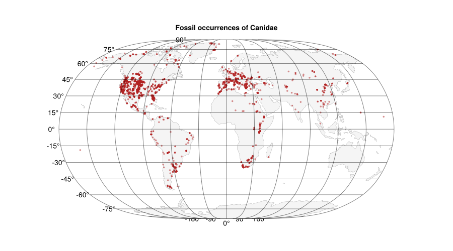

```julia
fig = Figure(size = (900, 500))

ga = GeoAxis(
    fig[1, 1];
    dest        = "+proj=natearth2",
    title       = "Fossil occurrences of Canidae",
    xlabel      = "Longitude",
    ylabel      = "Latitude",
)

## Draw land outlines as filled polygons
poly!(ga, GeoMakie.land(); color = :whitesmoke, strokecolor = :gray60, strokewidth = 0.4)

## Overlay occurrence points
scatter!(
    ga,
    canids_geo.lng,
    canids_geo.lat;
    color      = (:firebrick, 0.5),
    markersize = 5,
)

fig
```

**Tip`GeoMakie.land()`**

`GeoMakie.land()` returns a GeoJSON `FeatureCollection` containing the outlines of Earth’s land masses from the Natural Earth dataset, which is bundled with GeoMakie. `poly!` knows how to render GeoJSON feature collections directly onto a `GeoAxis`.

The `color` argument for the occurrence scatter uses a tuple `(:firebrick, 0.5)`, where the second element is the *alpha* (opacity) channel — values run from 0.0 (transparent) to 1.0 (fully opaque). Partial transparency is useful here because many points overlap; reducing opacity lets overlapping density show through.

#### 2.10.2 Coloring by age

A single color for all points treats all epochs identically. We can encode the midpoint age as a color using a continuous colormap, which reveals whether canid occurrences in different parts of the world tend to be from different time periods.

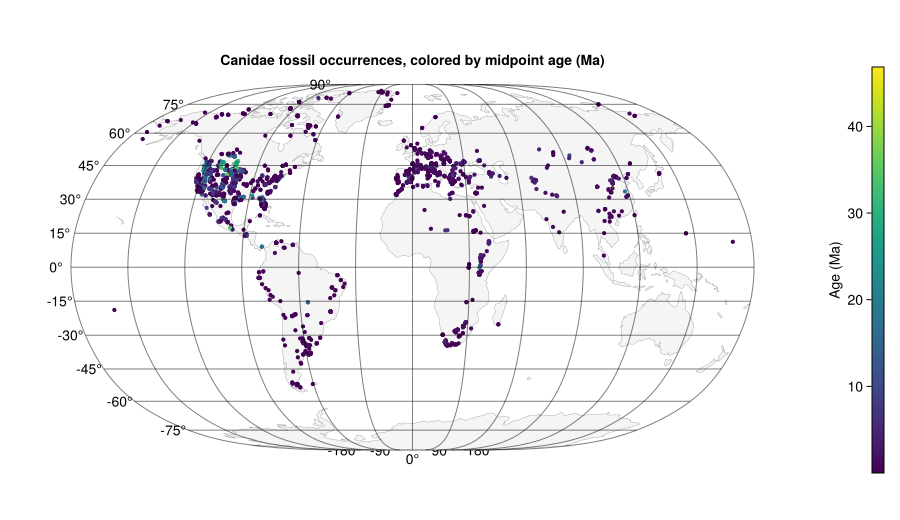

```julia
fig2 = Figure(size = (900, 520))

ga2 = GeoAxis(
    fig2[1, 1];
    dest  = "+proj=natearth2",
    title = "Canidae fossil occurrences, colored by midpoint age (Ma)",
)

poly!(ga2, GeoMakie.land(); color = :whitesmoke, strokecolor = :gray60, strokewidth = 0.4)

sc = scatter!(
    ga2,
    canids_geo.lng,
    canids_geo.lat;
    color      = canids_geo.mid_ma,
    colormap   = :viridis,
    markersize = 6,
)

Colorbar(fig2[1, 2], sc; label = "Age (Ma)", flipaxis = false)

fig2
```

**TipColorbars and the `Colorbar` function**

When `scatter!` is called with a numeric `color` vector and a `colormap`, it returns a plot object that carries the mapping from data values to colors. Passing that object to `Colorbar` creates a legend axis showing the color scale.

`fig2[1, 2]` places the colorbar in column 2 of the figure grid, to the right of the map. `flipaxis = false` puts the colorbar labels on the left side of the bar (adjacent to the map).

### 2.11 Temporal visualization

The geographic map shows *where* canids were found; a temporal plot shows *when*. The temporal distribution of fossil occurrences is a central quantity in paleontology: it reflects both the evolutionary history of the group and the preservational biases of the geological record.

#### 2.11.1 Distribution of midpoint ages

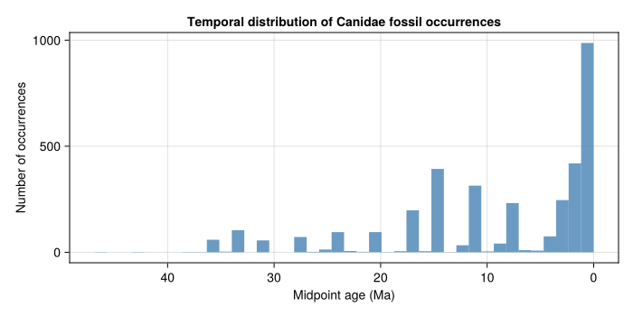

```julia
fig3 = Figure(size = (700, 350))
ax3  = Axis(
    fig3[1, 1];
    xlabel    = "Midpoint age (Ma)",
    ylabel    = "Number of occurrences",
    title     = "Temporal distribution of Canidae fossil occurrences",
    xreversed = true,
)

hist!(ax3, canids_geo.mid_ma; bins = 40, color = (:steelblue, 0.8))

fig3
```

**TipReversed time axis**

The `xreversed = true` keyword on `Axis` reverses the direction of the x-axis so that zero (the present) is on the right and the past extends leftward. This matches the stratigraphic convention used throughout the paleontological literature, where older strata are drawn deeper (lower or further left) than younger ones.

#### 2.11.2 Age uncertainty

Each record’s age is a *range* (`min_ma` to `max_ma`), not a precise date. We can visualise the spread of this uncertainty by plotting the width of each record’s age bracket:

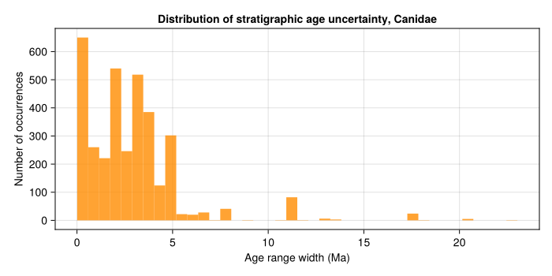

```julia
canids_geo = transform(
    canids_geo,
    [:min_ma, :max_ma] => ((lo, hi) -> hi .- lo) => :age_range_ma
)

fig4 = Figure(size = (700, 350))
ax4  = Axis(
    fig4[1, 1];
    xlabel = "Age range width (Ma)",
    ylabel = "Number of occurrences",
    title  = "Distribution of stratigraphic age uncertainty, Canidae",
)

hist!(ax4, canids_geo.age_range_ma; bins = 40, color = (:darkorange, 0.8))

fig4
```

Wide age ranges reflect coarse stratigraphic resolution in the original collections. Narrow ranges indicate that the fossil was found in a well-dated stratigraphic unit. The shape of this distribution is itself informative: it reflects how well-dated different parts of the geological record are for this taxon.

### 2.12 Putting it together: a reusable workflow

The steps above form a complete, repeatable pipeline. Here they are collected into a compact sequence that can be adapted for any taxon:

```julia
using PaleobiologyDB, DataFrames, CairoMakie, GeoMakie

## 1. Acquire
raw = pbdb_occurrences(
    base_name = "Canidae",
    show      = ["coords", "class"],
    vocab     = "pbdb",
    extids    = true,
)

## 2. Validate (coordinates and age bounds required)
clean = dropmissing(raw, [:lng, :lat, :min_ma, :max_ma])

## 3. Derive midpoint age
clean = transform(
    clean,
    [:min_ma, :max_ma] => ((lo, hi) -> (lo .+ hi) ./ 2) => :mid_ma
)

## 4. Map (colored by age)
fig = Figure(size = (900, 500))
ga  = GeoAxis(fig[1, 1]; dest = "+proj=natearth2", title = "Canidae occurrences")
poly!(ga, GeoMakie.land(); color = :whitesmoke, strokecolor = :gray60, strokewidth = 0.4)
sc  = scatter!(ga, clean.lng, clean.lat; color = clean.mid_ma, colormap = :viridis, markersize = 6)
Colorbar(fig[1, 2], sc; label = "Age (Ma)", flipaxis = false)
display(fig)

## 5. Temporal histogram
fig2 = Figure(size = (700, 350))
ax   = Axis(fig2[1, 1]; xlabel = "Midpoint age (Ma)", ylabel = "Occurrences", xreversed = true)
hist!(ax, clean.mid_ma; bins = 40, color = (:steelblue, 0.8))
display(fig2)
```

### 2.13 Exercises

**Exercise 2**

Repeat the complete workflow above for a different carnivoran family of your choice — for example `"Felidae"` (cats), `"Ursidae"` (bears), or `"Mustelidae"` (weasels and kin).

1. How many occurrence records does the PBDB hold for your chosen family?
2. How many were dropped due to missing coordinates?
3. Does the geographic distribution of occurrences match your expectation given what you know about the group’s present-day range?
4. What does the temporal histogram tell you about when the fossil record of this family is densest?

**Exercise 3**

The PBDB supports filtering by geographic bounding box using the `lngmin`, `lngmax`, `latmin`, and `latmax` parameters.

1. Retrieve Canidae occurrences restricted to North America (approximately `lngmin = -170`, `lngmax = -50`, `latmin = 15`, `latmax = 75`).
2. Retrieve Canidae occurrences restricted to Eurasia (approximately `lngmin = -10`, `lngmax = 180`, `latmin = 10`, `latmax = 75`).
3. Produce a single figure with two panels side by side — one histogram for each region — showing the temporal distribution of midpoint ages.
4. Do the two regions show different temporal patterns? What might explain any differences you observe?

*Hint:* To place two axes side by side, use `Axis(fig[1, 1]; ...)` and `Axis(fig[1, 2]; ...)`.

**Exercise 4**

Fossil occurrences from the PBDB come with a `genus` field (when `show = ["class"]` is requested and `vocab = "pbdb"` is set).

1. Using the `groupby` and `combine` functions from `DataFrames`, count the number of occurrences per genus in your cleaned Canidae dataset.
2. Sort the result by occurrence count in descending order.
3. Which five genera have the most fossil occurrences?
4. Produce a bar chart (use `barplot!` in CairoMakie) showing the top ten genera by occurrence count.

*Hint:* `groupby(df, :genus)` groups the rows; `combine(gdf, nrow => :count)` counts rows per group.

Back to top